# Investigating Movie Data

*Student: Ryan S.*

## Instructions

In this project, you will analyze a dataset and then communicate your findings about it. You will use the Python libraries NumPy, pandas, and Matplotlib to make your analysis easier. You should start by taking a look at your dataset and brainstorming what questions you could answer using it. Then you should use pandas and NumPy to answer the questions you are most interested in, and create a report sharing the answers. You will not be required to use inferential statistics or machine learning to complete this project, but you should make it clear in your communications that your findings are tentative. This project is open-ended in that we are not looking for one right answer.

Try and suggest questions that promote looking at relationships between multiple variables. You should aim to analyze at least one dependent variable and three independent variables in your investigation. Make sure you use NumPy and pandas where they are appropriate!

- Introduction
- Data Wrangling
  - Checking for Null Values
  - Understanding Production Company Data
  - Checking for Duplicate Data
- Data Cleanup
  - Dropping Null Columns
  - Dropping Null Rows
  - Resetting the Index
  - Dropping Duplicate Rows
- Exploratory Data Analysis
  - Question 1
    - Dealing with Zeros
    - Success vs Failure
    - The Role of Budget and Revenue
      - Distributions - Budget vs Revenue
      - Budget vs Revenue Scatterplot with Regression
      - Heatmap
      - Considering Failures
  - Question 2
    - Create a Dataframe 'Toprev'
    - Runtime
      - Runtime vs Revenue Scatterplot with Regression
      - Runtime Distribution
      - Toprev Heatmap
      - Runtime Summary
    - Vote Count
      - Vote Count vs Revenue Scatterplot with Regression
      - Vote Count vs Year
      - Vote Count vs Revenue
    - Genres
      - Splitting the Genres Column
      - Counting Genres
      - Number of Genres per Movie
      - Genres and Revenue
      - Genres Summary
- Conclusions

# Introduction

In this report, I chose to analyze the TMDb (The Movie Database) dataset. The dataset contains information on movies from the 1960s through 2015, and includes financial information, ratings, release dates, actors, studios, and more.

In my first question, I am going to look at what makes a movie a success or a failure, and dig deeper into why that might be.

In my second question, I am going to look at what some of the properties are of high revenue movies.

# Data Wrangling

## General Properties

I start by importing the libraries and dataset, and then get a cursory look at the data I will be working with.

```python
# Import Libraries
import pandas as pd
import numpy as np
import matplotlib.pyplot as plt
% matplotlib inline
import seaborn as sns
import scipy.stats  as stats
import warnings
warnings.filterwarnings('ignore')

# Centers all charts in the document
from IPython.core.display import HTML
HTML("""
<style>
.output_png {
    display: table-cell;
    text-align: center;
    vertical-align: middle;
}
</style>
""")
```

```python
# Import the dataset
df = pd.read_csv('tmdb-movies.csv')
```

```python
# Checking the shape of the dataframe
df.shape
```

```
(10866, 21)
```

```python
# Setting the display options. I base this on the shape of the dataframe because I prefer to see all columns
#   when I initially view the data below.
pd.set_option('display.max_columns', 21)
```

```python
# Getting an initial look at the data
df.head(3)
```

|  | id | imdb_id | popularity | budget | revenue | original_title | cast | homepage | director | tagline | keywords | overview | runtime | genres | production_companies | release_date | vote_count | vote_average | release_year | budget_adj | revenue_adj |
| --- | --- | --- | --- | --- | --- | --- | --- | --- | --- | --- | --- | --- | --- | --- | --- | --- | --- | --- | --- | --- | --- |
| 0 | 135397 | tt0369610 | 32.985763 | 150000000 | 1513528810 | Jurassic World | Chris Pratt\|Bryce Dallas Howard\|Irrfan Khan\|Vi... | http://www.jurassicworld.com/ | Colin Trevorrow | The park is open. | monster\|dna\|tyrannosaurus rex\|velociraptor\|island | Twenty-two years after the events of Jurassic ... | 124 | Action\|Adventure\|Science Fiction\|Thriller | Universal Studios\|Amblin Entertainment\|Legenda... | 6/9/15 | 5562 | 6.5 | 2015 | 1.379999e+08 | 1.392446e+09 |
| 1 | 76341 | tt1392190 | 28.419936 | 150000000 | 378436354 | Mad Max: Fury Road | Tom Hardy\|Charlize Theron\|Hugh Keays-Byrne\|Nic... | http://www.madmaxmovie.com/ | George Miller | What a Lovely Day. | future\|chase\|post-apocalyptic\|dystopia\|australia | An apocalyptic story set in the furthest reach... | 120 | Action\|Adventure\|Science Fiction\|Thriller | Village Roadshow Pictures\|Kennedy Miller Produ... | 5/13/15 | 6185 | 7.1 | 2015 | 1.379999e+08 | 3.481613e+08 |
| 2 | 262500 | tt2908446 | 13.112507 | 110000000 | 295238201 | Insurgent | Shailene Woodley\|Theo James\|Kate Winslet\|Ansel... | http://www.thedivergentseries.movie/#insurgent | Robert Schwentke | One Choice Can Destroy You | based on novel\|revolution\|dystopia\|sequel\|dyst... | Beatrice Prior must confront her inner demons ... | 119 | Adventure\|Science Fiction\|Thriller | Summit Entertainment\|Mandeville Films\|Red Wago... | 3/18/15 | 2480 | 6.3 | 2015 | 1.012000e+08 | 2.716190e+08 |

```python
# Checking data types and count of non-null values
df.info()
```

```
<class 'pandas.core.frame.DataFrame'>
RangeIndex: 10866 entries, 0 to 10865
Data columns (total 21 columns):
id                      10866 non-null int64
imdb_id                 10856 non-null object
popularity              10866 non-null float64
budget                  10866 non-null int64
revenue                 10866 non-null int64
original_title          10866 non-null object
cast                    10790 non-null object
homepage                2936 non-null object
director                10822 non-null object
tagline                 8042 non-null object
keywords                9373 non-null object
overview                10862 non-null object
runtime                 10866 non-null int64
genres                  10843 non-null object
production_companies    9836 non-null object
release_date            10866 non-null object
vote_count              10866 non-null int64
vote_average            10866 non-null float64
release_year            10866 non-null int64
budget_adj              10866 non-null float64
revenue_adj             10866 non-null float64
dtypes: float64(4), int64(6), object(11)
memory usage: 1.7+ MB
```

### General Properties Summary

The dataset has just under 11,000 rows of data in 21 columns. Some of the columns already appear to be unnecessary based on the contents, such as `tagline`. It also looks like there is some missing data. I will explore that below.

Back to Top

## Checking for Null Values

Here, I have created a more informative output, showing total nulls per column and calculating the percent. I have temporarily restricted the decimal points to two, and limited the results to only those columns which contain nulls.

```python
# Checking for Null Values
total = df.isnull().sum().sort_values(ascending=False)
percent = ((df.isnull().sum()/df.isnull().count())*100).sort_values(ascending=False)
missing = pd.concat([total, percent], axis=1, keys=['Total', 'Percent'])
pd.set_option('precision', 2)
missing[missing.Total > 0]
```

|  | Total | Percent |
| --- | --- | --- |
| homepage | 7930 | 72.98 |
| tagline | 2824 | 25.99 |
| keywords | 1493 | 13.74 |
| production_companies | 1030 | 9.48 |
| cast | 76 | 0.70 |
| director | 44 | 0.40 |
| genres | 23 | 0.21 |
| imdb_id | 10 | 0.09 |
| overview | 4 | 0.04 |

```python
# Reseting the decimal point restriction back to default.
pd.reset_option("precision")
```

### Null Summary

There is a high number of null values in columns that are not going to be relevant to my analysis. There is also a smaller number of null values in columns I may want to use.

My initial thought is that the columns with a high null count can simply be dropped, though I want to take a closer look at `production_companies` before I make a decision to drop it or not.

The columns that have a smaller number of null values could be kept, and instead delete the rows that have the null values since the entire dataset has over 10,000 rows.

Back to Top

## Understanding Production Company Data

There are 1030 null values in the `production_companies` column. I want to explore the data a little to see what is there (or not there) to work with.

```python
# Create a dataframe that shows all rows where production_companies has a null value
pc = df[df["production_companies"].isnull()]
```

```python
pc
```

[output not shown]

1030 rows × 21 columns

Right away, what jumps out at me is that there are a lot of zero's for budget and revenue, so I want to see how many rows have zero's for those columns.

```python
# Counts the number of zero values in the revenue column
pc.query('revenue == 0').revenue.count()
```

```
934
```

```python
# Calculates the percent of rows where revenue has a value of zero
pc.query('revenue == 0').revenue.count()/len(pc) * 100
```

```
90.67961165048544
```

There are 934 rows that are null for `production_companies` with a revenue of zero.

```python
# Counts the number of zero values in the budget column
pc.query('budget == 0').revenue.count()
```

```
894
```

```python
# Calculates the percent of rows where budget has a value of zero
pc.query('budget == 0').revenue.count()/len(pc) * 100
```

```
86.79611650485437
```

There are 894 rows that are null for `production_companies` and with a budget of zero.

```python
# Shows the number of rows where both budget and revenue have a value of zero
pc.groupby(["budget", "revenue"]).size().nlargest()
```

```
budget   revenue
0        0          844
2000000  0            7
3000000  0            5
6000000  0            5
5000000  0            4
dtype: int64
```

### Production Company Data Summary

Out of the 1030 rows where `production_companies` data is null, approximately 86-90% of the budget and revenue rows have zeroes for values, and both columns had zeros 844 times.

Because there are so many null or zero values for `production_companies`, `budget`, and `revenue` (and consequently `budget_adj` and `revenue_adj`) I have decided to drop rows where `production_companies` is null but keep the column for now. I don't know yet if it will be useful.

Back to Top

## Checking for Duplicate Data

Here I want to check to see if there is any duplicated data.

```python
# Counting duplicates
df.duplicated().sum()
```

```
1
```

```python
# Counting duplicate fields
df[df.duplicated(keep=False)].count()
```

```
id                      2
imdb_id                 2
popularity              2
budget                  2
revenue                 2
original_title          2
cast                    2
homepage                0
director                2
tagline                 2
keywords                2
overview                2
runtime                 2
genres                  2
production_companies    2
release_date            2
vote_count              2
vote_average            2
release_year            2
budget_adj              2
revenue_adj             2
dtype: int64
```

It appears there is one row of duplicate data. I'm going to find that row below.

```python
# Shows any duplicated row
df[df.duplicated()]
```

|  | id | imdb_id | popularity | budget | revenue | original_title | cast | homepage | director | tagline | keywords | overview | runtime | genres | production_companies | release_date | vote_count | vote_average | release_year | budget_adj | revenue_adj |
| --- | --- | --- | --- | --- | --- | --- | --- | --- | --- | --- | --- | --- | --- | --- | --- | --- | --- | --- | --- | --- | --- |
| 2090 | 42194 | tt0411951 | 0.59643 | 30000000 | 967000 | TEKKEN | Jon Foo\|Kelly Overton\|Cary-Hiroyuki Tagawa\|Ian... | NaN | Dwight H. Little | Survival is no game | martial arts\|dystopia\|based on video game\|mart... | In the year of 2039, after World Wars destroy ... | 92 | Crime\|Drama\|Action\|Thriller\|Science Fiction | Namco\|Light Song Films | 3/20/10 | 110 | 5.0 | 2010 | 30000000.0 | 967000.0 |

```python
# Showing a range of rows where the duplicated row will appear
df[2088:2092]
```

|  | id | imdb_id | popularity | budget | revenue | original_title | cast | homepage | director | tagline | keywords | overview | runtime | genres | production_companies | release_date | vote_count | vote_average | release_year | budget_adj | revenue_adj |
| --- | --- | --- | --- | --- | --- | --- | --- | --- | --- | --- | --- | --- | --- | --- | --- | --- | --- | --- | --- | --- | --- |
| 2088 | 43931 | tt0872230 | 0.597254 | 25000000 | 19829957 | My Soul to Take | Max Thieriot\|John Magaro\|Denzel Whitaker\|Zena ... | NaN | Wes Craven | Only One Has The Power To Save Their Souls | soul\|serial killer\|slasher\|teenager | A serial killer returns to his hometown to sta... | 107 | Drama\|Horror\|Mystery\|Thriller | Relativity Media\|Rogue | 10/8/10 | 75 | 5.2 | 2010 | 25000000.0 | 19829957.0 |
| 2089 | 42194 | tt0411951 | 0.596430 | 30000000 | 967000 | TEKKEN | Jon Foo\|Kelly Overton\|Cary-Hiroyuki Tagawa\|Ian... | NaN | Dwight H. Little | Survival is no game | martial arts\|dystopia\|based on video game\|mart... | In the year of 2039, after World Wars destroy ... | 92 | Crime\|Drama\|Action\|Thriller\|Science Fiction | Namco\|Light Song Films | 3/20/10 | 110 | 5.0 | 2010 | 30000000.0 | 967000.0 |
| 2090 | 42194 | tt0411951 | 0.596430 | 30000000 | 967000 | TEKKEN | Jon Foo\|Kelly Overton\|Cary-Hiroyuki Tagawa\|Ian... | NaN | Dwight H. Little | Survival is no game | martial arts\|dystopia\|based on video game\|mart... | In the year of 2039, after World Wars destroy ... | 92 | Crime\|Drama\|Action\|Thriller\|Science Fiction | Namco\|Light Song Films | 3/20/10 | 110 | 5.0 | 2010 | 30000000.0 | 967000.0 |
| 2091 | 60309 | tt0968264 | 0.591206 | 25000000 | 15478800 | The Conspirator | Evan Rachel Wood\|James McAvoy\|Kevin Kline\|Robi... | http://www.conspiratorthemovie.com/ | Robert Redford | One bullet killed the President. But not one man. | president\|history\|conspiracy\|lawyer\|trial | Mary Surratt is the lone female charged as a c... | 122 | Crime\|Drama\|History | Wildwood Enterprises\|American Film Company | 9/10/10 | 78 | 5.9 | 2010 | 25000000.0 | 15478800.0 |

### Duplicate Data Summary

I see that row 2090, id 42194, is a duplicate. By viewing a range of rows, I verified that row 2090 is a duplicate of row 2089, so the duplicate can be dropped.

Back to Top

# Data Cleanup

Below are the things that need to be cleaned up:

- In addition to not being useful for my analysis, there are a large number of nulls in the columns `homepage, tagline`, and `keywords`. These columns will be dropped, along with the `overview` column.
- Rows with nulls in `production_companies` will be dropped because they have a lot of nulls in other columns as well, but I want to keep the column.
- The columns with a smaller amount of nulls, `cast, director, genres, imdb_id, and overview`, will have rows dropped and columns kept.
- Row 2090 can be dropped as a duplicate.

Columns with Nulls:

```
                      Total    Percent
homepage               7930  72.979937
tagline                2824  25.989324
keywords               1493  13.740107
production_companies   1030   9.479109
cast                     76   0.699429
director                 44   0.404933
genres                   23   0.211669
imdb_id                  10   0.092030
overview                  4   0.036812
```

Additionally, I am going to drop both `budget_adj` and `revenue_adj` because I do not intend to use that data. I feel that their sole purpose is to attempt to give the reader a kind of reference point in current dollar amounts to compare an older movie to a newer one, but I feel that is not an accurate reflection of how it would have performed in current times, and doesn't account for other variables, such as population growth. Also, the instructions said the dollar amounts were adjusted to 2010 inflation, but there are a lot of movies after 2010 in the dataset, so that renders both columns essentially inaccurate and pointless.

Back to Top

## Dropping Null Columns:

The columns below are unnecessary for analysis because the data is not useful, so they will be dropped. Also recall that some of them also had many null values.

```
                      Total  Percent
homepage               7930    72.98
tagline                2824    25.99
keywords               1493    13.74
overview                  4     0.04
```

I'm also dropping `budget_adj` and `revenue_adj` as discussed above.

```python
df.drop(['homepage', 'tagline', 'keywords', 'overview', 'budget_adj', 'revenue_adj'], axis=1, inplace=True)
```

```python
# Verifying that the columns have been dropped; sorted alphabetically to make it easier to confirm
df.isnull().sum().sort_index()
```

```
budget                     0
cast                      76
director                  44
genres                    23
id                         0
imdb_id                   10
original_title             0
popularity                 0
production_companies    1030
release_date               0
release_year               0
revenue                    0
runtime                    0
vote_average               0
vote_count                 0
dtype: int64
```

Back to Top

## Dropping Null Rows

These columns have a relatively small number of nulls compared to the entire dataset, which is over 10,000, and I want to keep the columns, so I'm going to delete the rows that have null values in these particular columns. The `production_companies` rows are being dropped for reasons discussed above.

```
                      Total  Percent
production_companies   1030     9.48
cast                     76     0.70
director                 44     0.40
genres                   23     0.21
imdb_id                  10     0.09
```

```python
df.dropna(subset=['cast', 'director', 'genres', 'imdb_id', 'production_companies'], inplace=True)
```

```python
# Viewing the data summary after dropping null columns and rows
df.info()
```

```
<class 'pandas.core.frame.DataFrame'>
Int64Index: 9771 entries, 0 to 10865
Data columns (total 15 columns):
id                      9771 non-null int64
imdb_id                 9771 non-null object
popularity              9771 non-null float64
budget                  9771 non-null int64
revenue                 9771 non-null int64
original_title          9771 non-null object
cast                    9771 non-null object
director                9771 non-null object
runtime                 9771 non-null int64
genres                  9771 non-null object
production_companies    9771 non-null object
release_date            9771 non-null object
vote_count              9771 non-null int64
vote_average            9771 non-null float64
release_year            9771 non-null int64
dtypes: float64(2), int64(6), object(7)
memory usage: 1.2+ MB
```

Back to Top

## Resetting the Index

After removing so many rows of data, I need to reset the index because the deleted rows leave gaps, and can cause problems later on (which will be shown with what I will do with duplicates below).

```python
# I know I only have 9771 rows, yet the last row has a much higher value of 10865
df.tail(1)
```

|  | id | imdb_id | popularity | budget | revenue | original_title | cast | director | runtime | genres | production_companies | release_date | vote_count | vote_average | release_year |
| --- | --- | --- | --- | --- | --- | --- | --- | --- | --- | --- | --- | --- | --- | --- | --- |
| 10865 | 22293 | tt0060666 | 0.035919 | 19000 | 0 | Manos: The Hands of Fate | Harold P. Warren\|Tom Neyman\|John Reynolds\|Dian... | Harold P. Warren | 74 | Horror | Norm-Iris | 11/15/66 | 15 | 1.5 | 1966 |

```python
# Reset the index
df = df.reset_index(drop=True)
```

```python
# Verifying the reindexing worked. I know I have 9771 rows, so the last row should be 9770.
df.tail(1)
```

|  | id | imdb_id | popularity | budget | revenue | original_title | cast | director | runtime | genres | production_companies | release_date | vote_count | vote_average | release_year |
| --- | --- | --- | --- | --- | --- | --- | --- | --- | --- | --- | --- | --- | --- | --- | --- |
| 9770 | 22293 | tt0060666 | 0.035919 | 19000 | 0 | Manos: The Hands of Fate | Harold P. Warren\|Tom Neyman\|John Reynolds\|Dian... | Harold P. Warren | 74 | Horror | Norm-Iris | 11/15/66 | 15 | 1.5 | 1966 |

Back to Top

## Dropping Duplicate Rows

In the data wrangling section, I determined row 2090 was a duplicate. However, after deleting so many rows, if you try to look at row 2090 you get the wrong output. I needed to reset the index, which was done above, and now the duplicate row is no longer at 2090, so I have to find it again.

**Note:** I realize now that I should have resolved any issues with specific rows that I found during data wrangling first, and save dropping rows for last. Then I only have to reset the index once, and I don't have to take the steps to "refind" the rows I need to work with.

```python
# Finding the duplicate row's new index number
df[df.duplicated()]
```

|  | id | imdb_id | popularity | budget | revenue | original_title | cast | director | runtime | genres | production_companies | release_date | vote_count | vote_average | release_year |
| --- | --- | --- | --- | --- | --- | --- | --- | --- | --- | --- | --- | --- | --- | --- | --- |
| 1890 | 42194 | tt0411951 | 0.59643 | 30000000 | 967000 | TEKKEN | Jon Foo\|Kelly Overton\|Cary-Hiroyuki Tagawa\|Ian... | Dwight H. Little | 92 | Crime\|Drama\|Action\|Thriller\|Science Fiction | Namco\|Light Song Films | 3/20/10 | 110 | 5.0 | 2010 |

```python
# Now that I have the new row number, I can drop it
df.drop(df.index[[1890]], inplace=True)
```

```python
# Confirming that row 1890 was dropped.
df[1889:1891]
```

|  | id | imdb_id | popularity | budget | revenue | original_title | cast | director | runtime | genres | production_companies | release_date | vote_count | vote_average | release_year |
| --- | --- | --- | --- | --- | --- | --- | --- | --- | --- | --- | --- | --- | --- | --- | --- |
| 1889 | 42194 | tt0411951 | 0.596430 | 30000000 | 967000 | TEKKEN | Jon Foo\|Kelly Overton\|Cary-Hiroyuki Tagawa\|Ian... | Dwight H. Little | 92 | Crime\|Drama\|Action\|Thriller\|Science Fiction | Namco\|Light Song Films | 3/20/10 | 110 | 5.0 | 2010 |
| 1891 | 60309 | tt0968264 | 0.591206 | 25000000 | 15478800 | The Conspirator | Evan Rachel Wood\|James McAvoy\|Kevin Kline\|Robi... | Robert Redford | 122 | Crime\|Drama\|History | Wildwood Enterprises\|American Film Company | 9/10/10 | 78 | 5.9 | 2010 |

```python
# Resetting the index again to account for the missing row
df = df.reset_index(drop=True)
```

```python
# Confirming the resetting of the index.
# Note how the contents of the bottom row below matches the bottom row above, but with a different index number.
df[1889:1891]
```

|  | id | imdb_id | popularity | budget | revenue | original_title | cast | director | runtime | genres | production_companies | release_date | vote_count | vote_average | release_year |
| --- | --- | --- | --- | --- | --- | --- | --- | --- | --- | --- | --- | --- | --- | --- | --- |
| 1889 | 42194 | tt0411951 | 0.596430 | 30000000 | 967000 | TEKKEN | Jon Foo\|Kelly Overton\|Cary-Hiroyuki Tagawa\|Ian... | Dwight H. Little | 92 | Crime\|Drama\|Action\|Thriller\|Science Fiction | Namco\|Light Song Films | 3/20/10 | 110 | 5.0 | 2010 |
| 1890 | 60309 | tt0968264 | 0.591206 | 25000000 | 15478800 | The Conspirator | Evan Rachel Wood\|James McAvoy\|Kevin Kline\|Robi... | Robert Redford | 122 | Crime\|Drama\|History | Wildwood Enterprises\|American Film Company | 9/10/10 | 78 | 5.9 | 2010 |

```python
df.isnull().sum()
```

```
id                      0
imdb_id                 0
popularity              0
budget                  0
revenue                 0
original_title          0
cast                    0
director                0
runtime                 0
genres                  0
production_companies    0
release_date            0
vote_count              0
vote_average            0
release_year            0
dtype: int64
```

```python
df.info()
```

```
<class 'pandas.core.frame.DataFrame'>
RangeIndex: 9770 entries, 0 to 9769
Data columns (total 15 columns):
id                      9770 non-null int64
imdb_id                 9770 non-null object
popularity              9770 non-null float64
budget                  9770 non-null int64
revenue                 9770 non-null int64
original_title          9770 non-null object
cast                    9770 non-null object
director                9770 non-null object
runtime                 9770 non-null int64
genres                  9770 non-null object
production_companies    9770 non-null object
release_date            9770 non-null object
vote_count              9770 non-null int64
vote_average            9770 non-null float64
release_year            9770 non-null int64
dtypes: float64(2), int64(6), object(7)
memory usage: 1.1+ MB
```

Back to Top

## Dealing with Bad Data

During the course of my original exploratory analysis below, I came across a data point that seemed off to me. One of the movies had a budget of `$425,000,000`, the highest in the entire dataset. I had never heard of a movie with a budget that high, nor had I ever heard of the movie. I went to The Movie DB's website where this data was pulled from and looked up the movie and found that the budget was actually `$42,000,000`. I would have assumed that this data was pulled from their database, and that the same database would be queried for the display on their website. Apparently, that is not the case and it seems there may be some human error introduced into the dataset.

Since I can confirm that the dataset is wrong for that movie, I am going to change the value for that column to be the value that is stated on the website.

The reason I am explaining this here is because in that section, I went through about 10 steps before getting to the point of seeing this error, and if I fixed it in place I would have to redo those 10 steps, making this report longer and more confusing. Thus, I am changing it in the cleanup section and explaining the change now, and as a result I will get accurate results the first time.

```python
# Finding the row with the incorrect value for budget
df[df['original_title'].str.contains('The Warrior\'s Way')]
```

|  | id | imdb_id | popularity | budget | revenue | original_title | cast | director | runtime | genres | production_companies | release_date | vote_count | vote_average | release_year |
| --- | --- | --- | --- | --- | --- | --- | --- | --- | --- | --- | --- | --- | --- | --- | --- |
| 2030 | 46528 | tt1032751 | 0.25054 | 425000000 | 11087569 | The Warrior's Way | Kate Bosworth\|Jang Dong-gun\|Geoffrey Rush\|Dann... | Sngmoo Lee | 100 | Adventure\|Fantasy\|Action\|Western\|Thriller | Boram Entertainment Inc. | 12/2/10 | 74 | 6.4 | 2010 |

```python
# Changing the value of budget at row 2030
df.at[2030, 'budget'] = 42000000
```

```python
# Verifying the value has been changed
df[2030:2031]
```

|  | id | imdb_id | popularity | budget | revenue | original_title | cast | director | runtime | genres | production_companies | release_date | vote_count | vote_average | release_year |
| --- | --- | --- | --- | --- | --- | --- | --- | --- | --- | --- | --- | --- | --- | --- | --- |
| 2030 | 46528 | tt1032751 | 0.25054 | 42000000 | 11087569 | The Warrior's Way | Kate Bosworth\|Jang Dong-gun\|Geoffrey Rush\|Dann... | Sngmoo Lee | 100 | Adventure\|Fantasy\|Action\|Western\|Thriller | Boram Entertainment Inc. | 12/2/10 | 74 | 6.4 | 2010 |

Back to Top

# Exploratory Data Analysis

## Question 1: What effect does budget and revenue have on the success of a movie?

### Explanation

Asking this question can bring about a lot of debate on what qualifies as a success. It is generally accepted that in order for a movie to be considered successful, it has to earn back at least twice it's budget. This is to account for not only the cost of making the film, but also the massive marketing campaign that frequently accompanies these films, which isn't included in the budget and can sometimes even exceed the cost of production. This is not a firm line that must be met, but that is the guideline I am going to use for this report.

Below are two links to web pages that discuss this:

https://io9.gizmodo.com/5747305/how-much-money-does-a-movie-need-to-make-to-be-profitable

https://www.quora.com/What-are-the-criteria-for-a-movie-hit-super-hit-blockbuster-and-flop see first 2 answers

The reason this question is important is because determining the success can indicate whether a studio will make a sequel or something similar in the future. Even if the net exceeds the budget, if the movie can't make up for the cost of promoting it, then the chances they will make another goes down.

I realize that this is a broad question that could go in many different directions. For this project, I am going to focus on the financial aspect.

## Dealing with Zeros

This question deals with the financial columns of the dataset, so the data needs to be altered to deal with all the zeros that are in the `budget` and `revenue` columns. If I leave the zeros in, it will result in false analysis. I tested this beforehand, and having a zero makes a movie a failure by default, which skews the data heavily on the failure side. I don't know if the zeros mean they didn't make any money or if they simply don't have the data, but since there so many zeros in the budget column, I lean towards them not having the info.

To deal with this, these rows will need to be removed, which will significanly reduce the dataset. However, there will still be close to 4000 rows of data to work with. If we assume that the average movie is 2 hours long, and all you did was watch movies 24 hours a day, it would take over 10 months to get through them all! That is plenty of movies to work with.

If I was presented with a dataset like this on the job, I would take additional steps to find out if I could get the missing data, and if not, why not. In this case, I can only work with what I have currently.

```python
# Getting a count of the number of rows with a value of zero in the budget column
df[df.budget == 0].budget.count()
```

```
4749
```

```python
df.shape
```

```
(9770, 15)
```

```python
# Creating a new dataframe 'dfnz' and leaving out rows where budget = zero
dfnz = df[df.budget != 0]
```

```python
# This shows that the number of rows has dropped from 9770 to 5021
dfnz.info()
```

```
<class 'pandas.core.frame.DataFrame'>
Int64Index: 5021 entries, 0 to 9769
Data columns (total 15 columns):
id                      5021 non-null int64
imdb_id                 5021 non-null object
popularity              5021 non-null float64
budget                  5021 non-null int64
revenue                 5021 non-null int64
original_title          5021 non-null object
cast                    5021 non-null object
director                5021 non-null object
runtime                 5021 non-null int64
genres                  5021 non-null object
production_companies    5021 non-null object
release_date            5021 non-null object
vote_count              5021 non-null int64
vote_average            5021 non-null float64
release_year            5021 non-null int64
dtypes: float64(2), int64(6), object(7)
memory usage: 627.6+ KB
```

```python
# Updating the dataframe to leave out rows where revenue = zero
dfnz = dfnz[dfnz.revenue != 0]
```

```python
dfnz.info()
```

```
<class 'pandas.core.frame.DataFrame'>
Int64Index: 3805 entries, 0 to 9753
Data columns (total 15 columns):
id                      3805 non-null int64
imdb_id                 3805 non-null object
popularity              3805 non-null float64
budget                  3805 non-null int64
revenue                 3805 non-null int64
original_title          3805 non-null object
cast                    3805 non-null object
director                3805 non-null object
runtime                 3805 non-null int64
genres                  3805 non-null object
production_companies    3805 non-null object
release_date            3805 non-null object
vote_count              3805 non-null int64
vote_average            3805 non-null float64
release_year            3805 non-null int64
dtypes: float64(2), int64(6), object(7)
memory usage: 475.6+ KB
```

```python
dfnz.tail()
```

|  | id | imdb_id | popularity | budget | revenue | original_title | cast | director | runtime | genres | production_companies | release_date | vote_count | vote_average | release_year |
| --- | --- | --- | --- | --- | --- | --- | --- | --- | --- | --- | --- | --- | --- | --- | --- |
| 9728 | 396 | tt0061184 | 0.670274 | 7500000 | 33736689 | Who's Afraid of Virginia Woolf? | Elizabeth Taylor\|Richard Burton\|George Segal\|S... | Mike Nichols | 131 | Drama | Chenault Productions | 6/21/66 | 74 | 7.5 | 1966 |
| 9734 | 5780 | tt0061107 | 0.402730 | 3000000 | 13000000 | Torn Curtain | Paul Newman\|Julie Andrews\|Lila Kedrova\|HansjÃ¶... | Alfred Hitchcock | 128 | Mystery\|Thriller | Universal Pictures | 7/13/66 | 46 | 6.3 | 1966 |
| 9735 | 6644 | tt0061619 | 0.395668 | 4653000 | 6000000 | El Dorado | John Wayne\|Robert Mitchum\|James Caan\|Charlene ... | Howard Hawks | 120 | Action\|Western | Paramount Pictures\|Laurel Productions | 12/17/66 | 36 | 6.9 | 1966 |
| 9741 | 5923 | tt0060934 | 0.299911 | 12000000 | 20000000 | The Sand Pebbles | Steve McQueen\|Richard Attenborough\|Richard Cre... | Robert Wise | 182 | Action\|Adventure\|Drama\|War\|Romance | Twentieth Century Fox Film Corporation\|Solar P... | 12/20/66 | 28 | 7.0 | 1966 |
| 9753 | 2161 | tt0060397 | 0.207257 | 5115000 | 12000000 | Fantastic Voyage | Stephen Boyd\|Raquel Welch\|Edmond O'Brien\|Donal... | Richard Fleischer | 100 | Adventure\|Science Fiction | Twentieth Century Fox Film Corporation | 8/24/66 | 42 | 6.7 | 1966 |

```python
# Resetting the index to account for the deleted rows
dfnz = dfnz.reset_index(drop=True)
```

```python
# Confirming the index reset; I know I have 3805 rows of data, so the last row should be 3804
dfnz.tail(1)
```

|  | id | imdb_id | popularity | budget | revenue | original_title | cast | director | runtime | genres | production_companies | release_date | vote_count | vote_average | release_year |
| --- | --- | --- | --- | --- | --- | --- | --- | --- | --- | --- | --- | --- | --- | --- | --- |
| 3804 | 2161 | tt0060397 | 0.207257 | 5115000 | 12000000 | Fantastic Voyage | Stephen Boyd\|Raquel Welch\|Edmond O'Brien\|Donal... | Richard Fleischer | 100 | Adventure\|Science Fiction | Twentieth Century Fox Film Corporation | 8/24/66 | 42 | 6.7 | 1966 |

### Dealing with Zeros Summary

In the new dataset, `dfnz`, I still have 3805 rows of data, the index has been reset, and all the rows with zeros in the budget and revenue columns have been removed.

Back to Top

## Create a Column Called 'Net'

I am subtracting `budget` from `revenue` and putting it in a new column called `net`. This is how much money the movie actually made after accounting for their budget.

```python
# Create a new column 'net' and subtracting budget from revenue
dfnz['net'] = dfnz[['revenue']].sub(dfnz['budget'], axis=0)
```

```python
dfnz.head(2)
```

|  | id | imdb_id | popularity | budget | revenue | original_title | cast | director | runtime | genres | production_companies | release_date | vote_count | vote_average | release_year | net |
| --- | --- | --- | --- | --- | --- | --- | --- | --- | --- | --- | --- | --- | --- | --- | --- | --- |
| 0 | 135397 | tt0369610 | 32.985763 | 150000000 | 1513528810 | Jurassic World | Chris Pratt\|Bryce Dallas Howard\|Irrfan Khan\|Vi... | Colin Trevorrow | 124 | Action\|Adventure\|Science Fiction\|Thriller | Universal Studios\|Amblin Entertainment\|Legenda... | 6/9/15 | 5562 | 6.5 | 2015 | 1363528810 |
| 1 | 76341 | tt1392190 | 28.419936 | 150000000 | 378436354 | Mad Max: Fury Road | Tom Hardy\|Charlize Theron\|Hugh Keays-Byrne\|Nic... | George Miller | 120 | Action\|Adventure\|Science Fiction\|Thriller | Village Roadshow Pictures\|Kennedy Miller Produ... | 5/13/15 | 6185 | 7.1 | 2015 | 228436354 |

## Create a Column 'Profit'

I am creating a column called `profit` where I take `revenue - (budget * 2)` to account for the marketing campaign as discussed in the question explanation. If the value in the `profit` column is greater than zero, it means the movie made at least double its budget or higher. Less than zero means it did not double its budget.

```python
# Create a column 'profit' and subtracting budget times two from revenue
dfnz['profit'] = dfnz['revenue'].sub(dfnz['budget'] * 2, axis=0)
```

```python
dfnz.head(2)
```

|  | id | imdb_id | popularity | budget | revenue | original_title | cast | director | runtime | genres | production_companies | release_date | vote_count | vote_average | release_year | net | profit |
| --- | --- | --- | --- | --- | --- | --- | --- | --- | --- | --- | --- | --- | --- | --- | --- | --- | --- |
| 0 | 135397 | tt0369610 | 32.985763 | 150000000 | 1513528810 | Jurassic World | Chris Pratt\|Bryce Dallas Howard\|Irrfan Khan\|Vi... | Colin Trevorrow | 124 | Action\|Adventure\|Science Fiction\|Thriller | Universal Studios\|Amblin Entertainment\|Legenda... | 6/9/15 | 5562 | 6.5 | 2015 | 1363528810 | 1213528810 |
| 1 | 76341 | tt1392190 | 28.419936 | 150000000 | 378436354 | Mad Max: Fury Road | Tom Hardy\|Charlize Theron\|Hugh Keays-Byrne\|Nic... | George Miller | 120 | Action\|Adventure\|Science Fiction\|Thriller | Village Roadshow Pictures\|Kennedy Miller Produ... | 5/13/15 | 6185 | 7.1 | 2015 | 228436354 | 78436354 |

Back to Top

## Creating a Column Called 'Success'

Here I am creating a new column called `success` that will populate with **'Success'** if the profit is greater than zero, and **'Failure'** if less than zero. Anything above zero indicates the movie earned back twice it's budget to account for the marketing campaign; less than zero they possibly still made more than the budget, but did not meet the criteria of success as discussed in the question explanation.

```python
# Create column 'success' and populate it
dfnz['success'] = np.where(dfnz['profit'] > 0, 'Success', 'Failure')
```

```python
dfnz.head(3)
```

|  | id | imdb_id | popularity | budget | revenue | original_title | cast | director | runtime | genres | production_companies | release_date | vote_count | vote_average | release_year | net | profit | success |
| --- | --- | --- | --- | --- | --- | --- | --- | --- | --- | --- | --- | --- | --- | --- | --- | --- | --- | --- |
| 0 | 135397 | tt0369610 | 32.985763 | 150000000 | 1513528810 | Jurassic World | Chris Pratt\|Bryce Dallas Howard\|Irrfan Khan\|Vi... | Colin Trevorrow | 124 | Action\|Adventure\|Science Fiction\|Thriller | Universal Studios\|Amblin Entertainment\|Legenda... | 6/9/15 | 5562 | 6.5 | 2015 | 1363528810 | 1213528810 | Success |
| 1 | 76341 | tt1392190 | 28.419936 | 150000000 | 378436354 | Mad Max: Fury Road | Tom Hardy\|Charlize Theron\|Hugh Keays-Byrne\|Nic... | George Miller | 120 | Action\|Adventure\|Science Fiction\|Thriller | Village Roadshow Pictures\|Kennedy Miller Produ... | 5/13/15 | 6185 | 7.1 | 2015 | 228436354 | 78436354 | Success |
| 2 | 262500 | tt2908446 | 13.112507 | 110000000 | 295238201 | Insurgent | Shailene Woodley\|Theo James\|Kate Winslet\|Ansel... | Robert Schwentke | 119 | Adventure\|Science Fiction\|Thriller | Summit Entertainment\|Mandeville Films\|Red Wago... | 3/18/15 | 2480 | 6.3 | 2015 | 185238201 | 75238201 | Success |

Back to Top

### Changing Column Order

I want to change the order of the columns to make it easier for the reader to see important data.

```python
# Getting a list of columns to copy and paste for my next statement
cols = list(dfnz.columns.values)
print(cols)
```

```
['id', 'imdb_id', 'popularity', 'budget', 'revenue', 'original_title', 'cast', 'director', 'runtime', 'genres', 'production_companies', 'release_date', 'vote_count', 'vote_average', 'release_year', 'net', 'profit', 'success']
```

```python
# Reordering the column names

dfnz = dfnz[['id', 'imdb_id', 'original_title', 'cast', 'director', 'runtime', 'genres', 'budget', 'revenue', 'net', 'profit', 'success', 'production_companies', 'release_date', 'release_year', 'vote_count', 'vote_average', 'popularity']]
```

```python
dfnz.head(2)
```

|  | id | imdb_id | original_title | cast | director | runtime | genres | budget | revenue | net | profit | success | production_companies | release_date | release_year | vote_count | vote_average | popularity |
| --- | --- | --- | --- | --- | --- | --- | --- | --- | --- | --- | --- | --- | --- | --- | --- | --- | --- | --- |
| 0 | 135397 | tt0369610 | Jurassic World | Chris Pratt\|Bryce Dallas Howard\|Irrfan Khan\|Vi... | Colin Trevorrow | 124 | Action\|Adventure\|Science Fiction\|Thriller | 150000000 | 1513528810 | 1363528810 | 1213528810 | Success | Universal Studios\|Amblin Entertainment\|Legenda... | 6/9/15 | 2015 | 5562 | 6.5 | 32.985763 |
| 1 | 76341 | tt1392190 | Mad Max: Fury Road | Tom Hardy\|Charlize Theron\|Hugh Keays-Byrne\|Nic... | George Miller | 120 | Action\|Adventure\|Science Fiction\|Thriller | 150000000 | 378436354 | 228436354 | 78436354 | Success | Village Roadshow Pictures\|Kennedy Miller Produ... | 5/13/15 | 2015 | 6185 | 7.1 | 28.419936 |

Back to Top

## Success vs Failure

Now that I have prepared the data to determine successes and failures, I can take the next step to see how many there are.

```python
# Getting a count of the success column values
sf = dfnz['success'].value_counts()
```

```python
sf
```

```
Success    2008
Failure    1797
Name: success, dtype: int64
```

```python
sf.sum()
```

```
3805
```

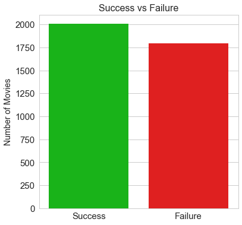

```python
# Using Seaborn to create a bar chart
sns.set(style="whitegrid", font_scale=1.5)
flatui = ["#00cc00", "#ff0000"]
sns.set_palette(flatui)
plt.figure(figsize=(6,6))
sns.barplot(sf.index, sf.values)
plt.title('Success vs Failure', fontsize=16)
plt.ylabel('Number of Movies', fontsize=14);
```

### Calculating the Ratio of Success : Failure

```python
sf.Success / 3805 * 100
```

```
52.77266754270696
```

```python
sf.Failure / 3805 * 100
```

```
47.22733245729304
```

### Failed with Positive Net

For some perspective, I wanted to see how many movies were considered failures yet still made money. For this, I just use the `net` value.

```python
# How many movies in the dataframe had a positive net value
len(dfnz.query('net > 0'))
```

```
2756
```

```python
# How many movies in the dataframe had a negative net value
len(dfnz.query('net < 0'))
```

```
1046
```

```python
# The number of movies with a positive net value subtracted by the number of movies considered successful
2756-2008
```

```
748
```

This shows that there were 748 movies that actually made money, but would not have be considered successful by the stated general guidelines of success.

### Summary of Success vs Failure

Overall, the movies in this dataset are considered successes more than failures, but it's close at 2008 to 1797. The results show a ratio of approximately 53:47. There were 748 movies that had a positive net value, but did not double their budget in revenue, which resulted in those movies being considered failures along with all the movies that had negative net values.

Back to Top

## The Role of Budget and Revenue

Since *'success'* was based on profit, and profit is based on budget and revenue, I want to analyze budget and revenue.

Let's look at the top 20 movies by revenue to keep things simple.

```python
dfnz.nlargest(20, 'revenue')
```

|  | id | imdb_id | original_title | cast | director | runtime | genres | budget | revenue | net | profit | success | production_companies | release_date | release_year | vote_count | vote_average | popularity |
| --- | --- | --- | --- | --- | --- | --- | --- | --- | --- | --- | --- | --- | --- | --- | --- | --- | --- | --- |
| 344 | 19995 | tt0499549 | Avatar | Sam Worthington\|Zoe Saldana\|Sigourney Weaver\|S... | James Cameron | 162 | Action\|Adventure\|Fantasy\|Science Fiction | 237000000 | 2781505847 | 2544505847 | 2307505847 | Success | Ingenious Film Partners\|Twentieth Century Fox ... | 12/10/09 | 2009 | 8458 | 7.1 | 9.432768 |
| 3 | 140607 | tt2488496 | Star Wars: The Force Awakens | Harrison Ford\|Mark Hamill\|Carrie Fisher\|Adam D... | J.J. Abrams | 136 | Action\|Adventure\|Science Fiction\|Fantasy | 200000000 | 2068178225 | 1868178225 | 1668178225 | Success | Lucasfilm\|Truenorth Productions\|Bad Robot | 12/15/15 | 2015 | 5292 | 7.5 | 11.173104 |
| 1746 | 597 | tt0120338 | Titanic | Kate Winslet\|Leonardo DiCaprio\|Frances Fisher\|... | James Cameron | 194 | Drama\|Romance\|Thriller | 200000000 | 1845034188 | 1645034188 | 1445034188 | Success | Paramount Pictures\|Twentieth Century Fox Film ... | 11/18/97 | 1997 | 4654 | 7.3 | 4.355219 |
| 1468 | 24428 | tt0848228 | The Avengers | Robert Downey Jr.\|Chris Evans\|Mark Ruffalo\|Chr... | Joss Whedon | 143 | Science Fiction\|Action\|Adventure | 220000000 | 1519557910 | 1299557910 | 1079557910 | Success | Marvel Studios | 4/25/12 | 2012 | 8903 | 7.3 | 7.637767 |
| 0 | 135397 | tt0369610 | Jurassic World | Chris Pratt\|Bryce Dallas Howard\|Irrfan Khan\|Vi... | Colin Trevorrow | 124 | Action\|Adventure\|Science Fiction\|Thriller | 150000000 | 1513528810 | 1363528810 | 1213528810 | Success | Universal Studios\|Amblin Entertainment\|Legenda... | 6/9/15 | 2015 | 5562 | 6.5 | 32.985763 |
| 4 | 168259 | tt2820852 | Furious 7 | Vin Diesel\|Paul Walker\|Jason Statham\|Michelle ... | James Wan | 137 | Action\|Crime\|Thriller | 190000000 | 1506249360 | 1316249360 | 1126249360 | Success | Universal Pictures\|Original Film\|Media Rights ... | 4/1/15 | 2015 | 2947 | 7.3 | 9.335014 |
| 14 | 99861 | tt2395427 | Avengers: Age of Ultron | Robert Downey Jr.\|Chris Hemsworth\|Mark Ruffalo... | Joss Whedon | 141 | Action\|Adventure\|Science Fiction | 280000000 | 1405035767 | 1125035767 | 845035767 | Success | Marvel Studios\|Prime Focus\|Revolution Sun Studios | 4/22/15 | 2015 | 4304 | 7.4 | 5.944927 |
| 1088 | 12445 | tt1201607 | Harry Potter and the Deathly Hallows: Part 2 | Daniel Radcliffe\|Rupert Grint\|Emma Watson\|Alan... | David Yates | 130 | Adventure\|Family\|Fantasy | 125000000 | 1327817822 | 1202817822 | 1077817822 | Success | Warner Bros.\|Heyday Films\|Moving Picture Compa... | 7/7/11 | 2011 | 3750 | 7.7 | 5.711315 |
| 1836 | 109445 | tt2294629 | Frozen | Kristen Bell\|Idina Menzel\|Jonathan Groff\|Josh ... | Chris Buck\|Jennifer Lee | 102 | Animation\|Adventure\|Family | 150000000 | 1274219009 | 1124219009 | 974219009 | Success | Walt Disney Pictures\|Walt Disney Animation Stu... | 11/27/13 | 2013 | 3369 | 7.5 | 6.112766 |
| 1839 | 68721 | tt1300854 | Iron Man 3 | Robert Downey Jr.\|Gwyneth Paltrow\|Guy Pearce\|D... | Shane Black | 130 | Action\|Adventure\|Science Fiction | 200000000 | 1215439994 | 1015439994 | 815439994 | Success | Marvel Studios | 4/18/13 | 2013 | 6882 | 6.9 | 4.946136 |
| 8 | 211672 | tt2293640 | Minions | Sandra Bullock\|Jon Hamm\|Michael Keaton\|Allison... | Kyle Balda\|Pierre Coffin | 91 | Family\|Animation\|Adventure\|Comedy | 74000000 | 1156730962 | 1082730962 | 1008730962 | Success | Universal Pictures\|Illumination Entertainment | 6/17/15 | 2015 | 2893 | 6.5 | 7.404165 |
| 1208 | 38356 | tt1399103 | Transformers: Dark of the Moon | Shia LaBeouf\|John Malkovich\|Ken Jeong\|Frances ... | Michael Bay | 154 | Action\|Science Fiction\|Adventure | 195000000 | 1123746996 | 928746996 | 733746996 | Success | Paramount Pictures\|Di Bonaventura Pictures\|Has... | 6/28/11 | 2011 | 2456 | 6.1 | 0.760503 |
| 1625 | 122 | tt0167260 | The Lord of the Rings: The Return of the King | Elijah Wood\|Ian McKellen\|Viggo Mortensen\|Liv T... | Peter Jackson | 201 | Adventure\|Fantasy\|Action | 94000000 | 1118888979 | 1024888979 | 930888979 | Success | WingNut Films\|New Line Cinema | 12/1/03 | 2003 | 5636 | 7.9 | 7.122455 |
| 1472 | 37724 | tt1074638 | Skyfall | Daniel Craig\|Judi Dench\|Javier Bardem\|Ralph Fi... | Sam Mendes | 143 | Action\|Adventure\|Thriller | 200000000 | 1108561013 | 908561013 | 708561013 | Success | Columbia Pictures | 10/25/12 | 2012 | 6137 | 6.8 | 5.603587 |
| 2828 | 1642 | tt0113957 | The Net | Sandra Bullock\|Jeremy Northam\|Dennis Miller\|We... | Irwin Winkler | 114 | Crime\|Drama\|Mystery\|Thriller\|Action | 22000000 | 1106279658 | 1084279658 | 1062279658 | Success | Columbia Pictures | 7/28/95 | 1995 | 201 | 5.6 | 1.136610 |
| 1470 | 49026 | tt1345836 | The Dark Knight Rises | Christian Bale\|Michael Caine\|Gary Oldman\|Anne ... | Christopher Nolan | 165 | Action\|Crime\|Drama\|Thriller | 250000000 | 1081041287 | 831041287 | 581041287 | Success | Legendary Pictures\|Warner Bros.\|DC Entertainme... | 7/16/12 | 2012 | 6723 | 7.5 | 6.591277 |
| 2216 | 58 | tt0383574 | Pirates of the Caribbean: Dead Man's Chest | Johnny Depp\|Orlando Bloom\|Keira Knightley\|Bill... | Gore Verbinski | 151 | Adventure\|Fantasy\|Action | 200000000 | 1065659812 | 865659812 | 665659812 | Success | Walt Disney Pictures\|Jerry Bruckheimer Films\|S... | 6/20/06 | 2006 | 3181 | 6.8 | 4.205992 |
| 525 | 10193 | tt0435761 | Toy Story 3 | Tom Hanks\|Tim Allen\|Ned Beatty\|Joan Cusack\|Mic... | Lee Unkrich | 103 | Animation\|Family\|Comedy | 200000000 | 1063171911 | 863171911 | 663171911 | Success | Walt Disney Pictures\|Pixar Animation Studios | 6/16/10 | 2010 | 2924 | 7.5 | 2.711136 |
| 516 | 12155 | tt1014759 | Alice in Wonderland | Mia Wasikowska\|Johnny Depp\|Anne Hathaway\|Helen... | Tim Burton | 108 | Family\|Fantasy\|Adventure | 200000000 | 1025467110 | 825467110 | 625467110 | Success | Walt Disney Pictures\|Team Todd\|Tim Burton Prod... | 3/3/10 | 2010 | 2853 | 6.3 | 5.572950 |
| 1089 | 1865 | tt1298650 | Pirates of the Caribbean: On Stranger Tides | Johnny Depp\|PenÃ©lope Cruz\|Geoffrey Rush\|Ian M... | Rob Marshall | 136 | Adventure\|Action\|Fantasy | 380000000 | 1021683000 | 641683000 | 261683000 | Success | Walt Disney Pictures\|Jerry Bruckheimer Films\|M... | 5/11/11 | 2011 | 3180 | 6.3 | 4.955130 |

Now, let's look at the top 20 movies with the highest budget.

```python
dfnz.nlargest(20, 'budget')
```

|  | id | imdb_id | original_title | cast | director | runtime | genres | budget | revenue | net | profit | success | production_companies | release_date | release_year | vote_count | vote_average | popularity |
| --- | --- | --- | --- | --- | --- | --- | --- | --- | --- | --- | --- | --- | --- | --- | --- | --- | --- | --- |
| 1089 | 1865 | tt1298650 | Pirates of the Caribbean: On Stranger Tides | Johnny Depp\|Penélope Cruz\|Geoffrey Rush\|Ian M... | Rob Marshall | 136 | Adventure\|Action\|Fantasy | 380000000 | 1021683000 | 641683000 | 261683000 | Success | Walt Disney Pictures\|Jerry Bruckheimer Films\|M... | 5/11/11 | 2011 | 3180 | 6.3 | 4.955130 |
| 2556 | 285 | tt0449088 | Pirates of the Caribbean: At World's End | Johnny Depp\|Orlando Bloom\|Keira Knightley\|Geof... | Gore Verbinski | 169 | Adventure\|Fantasy\|Action | 300000000 | 961000000 | 661000000 | 361000000 | Success | Walt Disney Pictures\|Jerry Bruckheimer Films\|S... | 5/19/07 | 2007 | 2626 | 6.8 | 4.965391 |
| 14 | 99861 | tt2395427 | Avengers: Age of Ultron | Robert Downey Jr.\|Chris Hemsworth\|Mark Ruffalo... | Joss Whedon | 141 | Action\|Adventure\|Science Fiction | 280000000 | 1405035767 | 1125035767 | 845035767 | Success | Marvel Studios\|Prime Focus\|Revolution Sun Studios | 4/22/15 | 2015 | 4304 | 7.4 | 5.944927 |
| 2230 | 1452 | tt0348150 | Superman Returns | Brandon Routh\|Kevin Spacey\|Kate Bosworth\|James... | Bryan Singer | 154 | Adventure\|Fantasy\|Action\|Science Fiction | 270000000 | 391081192 | 121081192 | -148918808 | Failure | DC Comics\|Legendary Pictures\|Warner Bros.\|Bad ... | 6/28/06 | 2006 | 834 | 5.3 | 1.957331 |
| 524 | 38757 | tt0398286 | Tangled | Zachary Levi\|Mandy Moore\|Donna Murphy\|Ron Perl... | Nathan Greno\|Byron Howard | 100 | Animation\|Family | 260000000 | 591794936 | 331794936 | 71794936 | Success | Walt Disney Pictures\|Walt Disney Animation Stu... | 11/24/10 | 2010 | 2019 | 7.3 | 2.865684 |
| 1513 | 49529 | tt0401729 | John Carter | Taylor Kitsch\|Lynn Collins\|Mark Strong\|Willem ... | Andrew Stanton | 132 | Action\|Adventure\|Fantasy\|Science Fiction | 260000000 | 284139100 | 24139100 | -235860900 | Failure | Walt Disney Pictures | 3/7/12 | 2012 | 1479 | 6.0 | 1.588457 |
| 2563 | 559 | tt0413300 | Spider-Man 3 | Tobey Maguire\|Kirsten Dunst\|James Franco\|Thoma... | Sam Raimi | 139 | Fantasy\|Action\|Adventure | 258000000 | 890871626 | 632871626 | 374871626 | Success | Columbia Pictures\|Laura Ziskin Productions\|Mar... | 5/1/07 | 2007 | 2083 | 5.8 | 2.520912 |
| 1910 | 57201 | tt1210819 | The Lone Ranger | Johnny Depp\|Armie Hammer\|William Fichtner\|Hele... | Gore Verbinski | 149 | Action\|Adventure\|Western | 255000000 | 89289910 | -165710090 | -420710090 | Failure | Walt Disney Pictures\|Jerry Bruckheimer Films\|I... | 7/3/13 | 2013 | 1607 | 6.0 | 1.214510 |
| 165 | 122917 | tt2310332 | The Hobbit: The Battle of the Five Armies | Martin Freeman\|Ian McKellen\|Richard Armitage\|K... | Peter Jackson | 144 | Adventure\|Fantasy | 250000000 | 955119788 | 705119788 | 455119788 | Success | WingNut Films\|New Line Cinema\|3Foot7\|Metro-Gol... | 12/10/14 | 2014 | 3110 | 7.1 | 10.174599 |
| 174 | 127585 | tt1877832 | X-Men: Days of Future Past | Hugh Jackman\|James McAvoy\|Patrick Stewart\|Mich... | Bryan Singer | 131 | Action\|Adventure\|Fantasy\|Science Fiction | 250000000 | 746000000 | 496000000 | 246000000 | Success | Twentieth Century Fox Film Corporation\|Donners... | 5/15/14 | 2014 | 4006 | 7.6 | 6.052479 |
| 347 | 767 | tt0417741 | Harry Potter and the Half-Blood Prince | Daniel Radcliffe\|Rupert Grint\|Emma Watson\|Tom ... | David Yates | 153 | Adventure\|Fantasy\|Family | 250000000 | 933959197 | 683959197 | 433959197 | Success | Warner Bros.\|Heyday Films | 7/7/09 | 2009 | 3220 | 7.3 | 5.076472 |
| 518 | 12444 | tt0926084 | Harry Potter and the Deathly Hallows: Part 1 | Daniel Radcliffe\|Emma Watson\|Rupert Grint\|Ralp... | David Yates | 146 | Adventure\|Fantasy\|Family | 250000000 | 954305868 | 704305868 | 454305868 | Success | Warner Bros.\|Heyday Films | 10/17/10 | 2010 | 3467 | 7.4 | 4.840588 |
| 1470 | 49026 | tt1345836 | The Dark Knight Rises | Christian Bale\|Michael Caine\|Gary Oldman\|Anne ... | Christopher Nolan | 165 | Action\|Crime\|Drama\|Thriller | 250000000 | 1081041287 | 831041287 | 581041287 | Success | Legendary Pictures\|Warner Bros.\|DC Entertainme... | 7/16/12 | 2012 | 6723 | 7.5 | 6.591277 |
| 1474 | 49051 | tt0903624 | The Hobbit: An Unexpected Journey | Ian McKellen\|Martin Freeman\|Richard Armitage\|A... | Peter Jackson | 169 | Adventure\|Fantasy\|Action | 250000000 | 1017003568 | 767003568 | 517003568 | Success | WingNut Films\|New Line Cinema\|Metro-Goldwyn-Ma... | 11/26/12 | 2012 | 6417 | 6.9 | 4.218933 |
| 1845 | 57158 | tt1170358 | The Hobbit: The Desolation of Smaug | Martin Freeman\|Ian McKellen\|Richard Armitage\|K... | Peter Jackson | 161 | Adventure\|Fantasy | 250000000 | 958400000 | 708400000 | 458400000 | Success | WingNut Films\|New Line Cinema\|Metro-Goldwyn-Ma... | 12/11/13 | 2013 | 2952 | 7.6 | 4.310786 |
| 10 | 206647 | tt2379713 | Spectre | Daniel Craig\|Christoph Waltz\|Léa Seydoux\|Ralp... | Sam Mendes | 148 | Action\|Adventure\|Crime | 245000000 | 880674609 | 635674609 | 390674609 | Success | Columbia Pictures\|Danjaq\|B24 | 10/26/15 | 2015 | 3254 | 6.2 | 6.200282 |
| 344 | 19995 | tt0499549 | Avatar | Sam Worthington\|Zoe Saldana\|Sigourney Weaver\|S... | James Cameron | 162 | Action\|Adventure\|Fantasy\|Science Fiction | 237000000 | 2781505847 | 2544505847 | 2307505847 | Success | Ingenious Film Partners\|Twentieth Century Fox ... | 12/10/09 | 2009 | 8458 | 7.1 | 9.432768 |
| 951 | 2454 | tt0499448 | The Chronicles of Narnia: Prince Caspian | Ben Barnes\|William Moseley\|Anna Popplewell\|Ska... | Andrew Adamson | 150 | Adventure\|Family\|Fantasy | 225000000 | 419651413 | 194651413 | -30348587 | Failure | Walt Disney\|Walden Media\|Stillking Films\|Ozumi... | 5/15/08 | 2008 | 891 | 6.1 | 1.628345 |
| 1488 | 41154 | tt1409024 | Men in Black 3 | Will Smith\|Tommy Lee Jones\|Josh Brolin\|Michael... | Barry Sonnenfeld | 106 | Action\|Comedy\|Science Fiction | 225000000 | 624026776 | 399026776 | 174026776 | Success | Amblin Entertainment\|Media Magik Entertainment... | 5/23/12 | 2012 | 3142 | 6.1 | 2.592896 |
| 1846 | 49521 | tt0770828 | Man of Steel | Henry Cavill\|Amy Adams\|Michael Shannon\|Diane L... | Zack Snyder | 143 | Action\|Adventure\|Fantasy\|Science Fiction | 225000000 | 662845518 | 437845518 | 212845518 | Success | Legendary Pictures\|Warner Bros.\|DC Entertainme... | 6/12/13 | 2013 | 4729 | 6.5 | 3.972460 |

### Observations

If budget were an indicator of revenue, and both were an indicator of success, I would expect these results to be similar. Instead, there are only 4 movies that appear in both queries. Additionally, there are 4 movies out of the 20 on the budget query that were also considered failures. This would indicate that a high budget is not necessarily a reflection of revenue, nor what is considered a success by the criteria in this report. I want to explore this further.

Back to Top

## Distributions - Budget vs Revenue

I'm going to look at each variable separately first, then together.

### Distributions

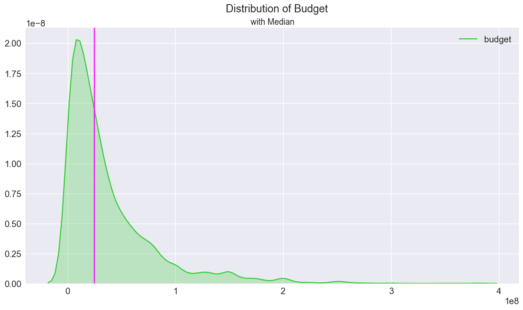

```python
# Create a kernel density estimate plot
plt.figure(figsize = (15,8))
sns.set(style="darkgrid", font_scale=1.5)
plt.suptitle('Distribution of Budget', x= .52, y=.95, fontsize=18)
plt.title('with Median', fontsize=14)
sns.kdeplot(dfnz["budget"], color='limegreen', shade=True);
plt.xlabel('');
plt.axvline(x=dfnz["budget"].median(), color = 'fuchsia');
```

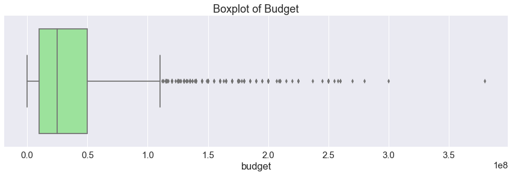

```python
# Create a boxplot
plt.figure(figsize = (15,4))
sns.set(style="darkgrid", font_scale=1.5)
sns.boxplot(data=dfnz, x='budget', color='lightgreen');
plt.title('Boxplot of Budget');
```

```python
dfnz.budget.median()
```

```
25000000.0
```

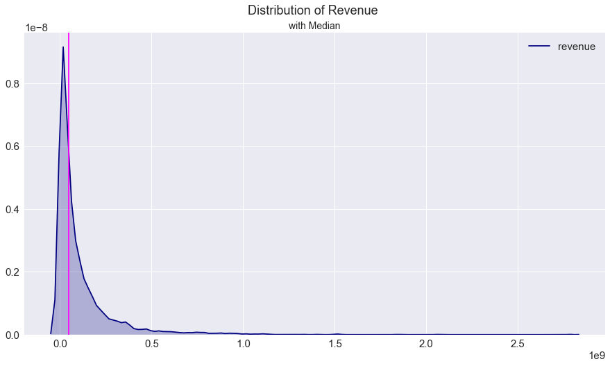

```python
# Create a kernel density estimate plot
plt.figure(figsize = (15,8))
sns.set(style="darkgrid", font_scale=1.5)
plt.suptitle('Distribution of Revenue', x= .51, y=.95, fontsize=18)
plt.title('with Median', fontsize=14)
sns.kdeplot(dfnz["revenue"], color='navy', shade=True);
plt.xlabel('');
plt.axvline(x=dfnz["revenue"].median(), color = 'fuchsia');
```

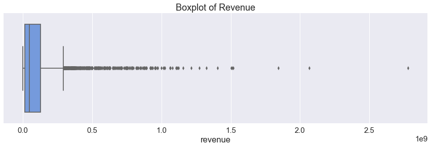

```python
# Create a boxplot
plt.figure(figsize = (15,4))
sns.set(style="darkgrid", font_scale=1.5)
sns.boxplot(data=dfnz, x='revenue', color='cornflowerblue');
plt.title('Boxplot of Revenue');
```

```python
dfnz.revenue.median()
```

```
46216641.0
```

#### Distributions Observations:

These distributions are highly right-skewed with outliers. The outliers are valid; those movies simply had higher budgets and revenue, so they can't simply be removed, but it will cause things to be skewed.

Back to Top

### Budget vs Revenue Scatterplot with Regression

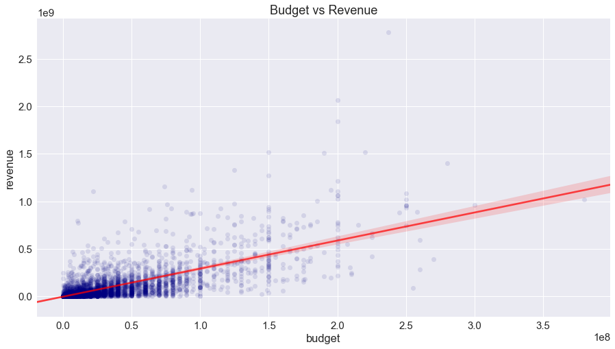

```python
# Creating a scatterplot with a regression line
plt.figure(figsize = (15,8))
sns.set(style="darkgrid", font_scale=1.5)
sns.regplot(x="budget", y="revenue", data=dfnz,
            scatter_kws={"color":"navy","alpha":0.1},
            line_kws={"color":"red","alpha":0.7});
plt.title('Budget vs Revenue');
```

#### Scatterplot Observations

In the plot above, the regression line seems to indicate a moderate trend where bigger budget leads to bigger revenue, though I wonder how much the big revenue movies are moving the regression line. I want to see the correlation statistics.

### Heatmap

A heatmap provides the same statistics as a `.corr` but the addition of color coding makes it much easier to see correlations.

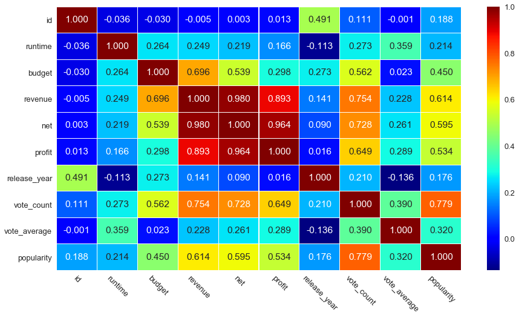

```python
# Create heatmap of dfnz
plt.figure(figsize = (15,8))
sns.set(font_scale=1.3)
g = sns.heatmap(dfnz[list(dfnz)].corr(), annot=True, fmt = ".3f", cmap = "jet", linewidths= 0.01)
plt.xticks(rotation=-45);
```

#### Heatmap Observations

The heatmap shows that budget and revenue have a correlation of 0.696, which is on the cusp between moderate and strong correlation. Having the actual number is beneficial, because the scatterplot above can be open to interpretation as to whether or not the correlation is moderate or strong.

Back to Top

### Considering Failures

I have been focused on `budget` and `revenue`, but recall that the *success vs failure* rates were pretty close to each other. What I've just shown is that there is somewhat of a correlation between `budget` and `revenue`, but the **failure rate** would indicate there are definitely some exceptions.

Below I am looking at `net` values that are negative, i.e, a loss. Specifically, any movie that has a `net` value of *negative* $10 million or more. `Net` has to be used because by definition you can't have negative `profit`.

```python
len(dfnz.query('net < -10000000'))
```

```
478
```

```python
len(dfnz.query('net < -10000000')) / len(dfnz) * 100
```

```
12.562417871222076
```

There are 478 movies that lost $10 million dollars or more. That turns out to be about 12.5% of the 3805 movies in this dataframe that lost a significant amount of money.

If you apply 12.5% failures to the full 9770 of the original dataset, that would be over 1200 movies that lost $10 million or more.

```python
# Getting the top 20 rows that lost the most money
dfnz.nsmallest(20, 'net')
```

|  | id | imdb_id | original_title | cast | director | runtime | genres | budget | revenue | net | profit | success | production_companies | release_date | release_year | vote_count | vote_average | popularity |
| --- | --- | --- | --- | --- | --- | --- | --- | --- | --- | --- | --- | --- | --- | --- | --- | --- | --- | --- |
| 1910 | 57201 | tt1210819 | The Lone Ranger | Johnny Depp\|Armie Hammer\|William Fichtner\|Hele... | Gore Verbinski | 149 | Action\|Adventure\|Western | 255000000 | 89289910 | -165710090 | -420710090 | Failure | Walt Disney Pictures\|Jerry Bruckheimer Films\|I... | 7/3/13 | 2013 | 1607 | 6.0 | 1.214510 |
| 2445 | 10733 | tt0318974 | The Alamo | Dennis Quaid\|Billy Bob Thornton\|Jason Patric\|P... | John Lee Hancock | 137 | Western\|History\|War | 145000000 | 25819961 | -119180039 | -264180039 | Failure | Imagine Entertainment\|Touchstone Pictures | 4/7/04 | 2004 | 60 | 5.9 | 0.948560 |
| 1182 | 50321 | tt1305591 | Mars Needs Moms | Seth Green\|Joan Cusack\|Dan Fogler\|Breckin Meye... | Simon Wells | 88 | Adventure\|Animation\|Family | 150000000 | 38992758 | -111007242 | -261007242 | Failure | Walt Disney Animation Studios | 3/9/11 | 2011 | 129 | 5.5 | 0.921653 |
| 1646 | 10009 | tt0328880 | Brother Bear | Joaquin Phoenix\|Jeremy Suarez\|Rick Moranis\|Joa... | Aaron Blaise\|Robert Walker | 85 | Animation\|Adventure\|Family\|Fantasy | 100000000 | 250 | -99999750 | -199999750 | Failure | Walt Disney Pictures\|Walt Disney Feature Anima... | 10/20/03 | 2003 | 753 | 6.8 | 1.653031 |
| 716 | 1911 | tt0120657 | The 13th Warrior | Antonio Banderas\|Vladimir Kulich\|Dennis StorhÃ... | John McTiernan | 102 | Adventure\|Fantasy\|Action | 160000000 | 61698899 | -98301101 | -258301101 | Failure | Touchstone Pictures | 8/27/99 | 1999 | 275 | 6.2 | 1.189386 |
| 1391 | 11692 | tt0180052 | The Adventures of Pluto Nash | Eddie Murphy\|Randy Quaid\|Rosario Dawson\|Joe Pa... | Ron Underwood | 95 | Action\|Comedy\|Science Fiction | 100000000 | 7103973 | -92896027 | -192896027 | Failure | Village Roadshow Pictures\|Castle Rock Entertai... | 8/15/02 | 2002 | 75 | 4.6 | 0.912373 |
| 2324 | 9986 | tt0413895 | Charlotte's Web | Julia Roberts\|Steve Buscemi\|John Cleese\|Oprah ... | Gary Winick | 97 | Comedy\|Family\|Fantasy | 85000000 | 144 | -84999856 | -169999856 | Failure | Paramount Pictures\|Kerner Entertainment Company | 12/15/06 | 2006 | 161 | 6.0 | 0.536631 |
| 2247 | 11619 | tt0424095 | Flushed Away | Hugh Jackman\|Kate Winslet\|Ian McKellen\|Jean Re... | David Bowers\|Sam Fell | 85 | Adventure\|Animation\|Comedy\|Family | 149000000 | 64459316 | -84540684 | -233540684 | Failure | Aardman Animations\|DreamWorks Animation | 10/22/06 | 2006 | 488 | 6.0 | 1.390297 |
| 963 | 6972 | tt0455824 | Australia | Nicole Kidman\|Hugh Jackman\|Essie Davis\|David W... | Baz Luhrmann | 165 | Drama | 130000000 | 49554002 | -80445998 | -210445998 | Failure | Bazmark Films\|Ingenious Film Partners\|Twentiet... | 11/18/08 | 2008 | 411 | 6.3 | 1.468543 |
| 2834 | 1408 | tt0112760 | Cutthroat Island | Geena Davis\|Matthew Modine\|Frank Langella\|Maur... | Renny Harlin | 119 | Action\|Adventure | 98000000 | 18517322 | -79482678 | -177482678 | Failure | Le Studio Canal+\|Laurence Mark Productions\|Met... | 12/22/95 | 1995 | 54 | 6.1 | 0.981049 |
| 3127 | 10384 | tt0134983 | Supernova | James Spader\|Angela Bassett\|Robert Forster\|Lou... | Walter Hill\|Jack Sholder | 91 | Science Fiction | 90000000 | 14828081 | -75171919 | -165171919 | Failure | United Artists\|Metro-Goldwyn-Mayer (MGM)\|Hamme... | 1/14/00 | 2000 | 42 | 4.7 | 0.385350 |
| 2159 | 10077 | tt0318081 | A Sound of Thunder | Heike Makatsch\|Armin Rohde\|David Oyelowo\|Wilfr... | Peter Hyams | 110 | Thriller\|Science Fiction\|Adventure\|Action | 80000000 | 5989640 | -74010360 | -154010360 | Failure | Epsilon Motion Pictures\|Franchise Pictures\|Bal... | 5/15/05 | 2005 | 58 | 4.8 | 0.626900 |
| 620 | 49852 | tt1041804 | The Nutcracker: The Untold Story | Nathan Lane\|John Turturro\|Frances de la Tour\|E... | Andrei Konchalovsky | 110 | Fantasy\|Action\|Family | 90000000 | 16178959 | -73821041 | -163821041 | Failure | Vnesheconombank\|Nutcracker Holdings\|HCC Media ... | 11/24/10 | 2010 | 28 | 5.8 | 0.764791 |
| 2609 | 13483 | tt0211933 | Awake | Hayden Christensen\|Jessica Alba\|Terrence Howar... | Joby Harold | 84 | Thriller\|Crime\|Mystery | 86000000 | 14373825 | -71626175 | -157626175 | Failure | The Weinstein Company\|Open City Films\|GreeneSt... | 11/28/07 | 2007 | 229 | 6.3 | 1.142781 |
| 634 | 42888 | tt1341188 | How Do You Know | Reese Witherspoon\|Paul Rudd\|Owen Wilson\|Jack N... | James L. Brooks | 121 | Comedy\|Drama\|Romance | 120000000 | 48668907 | -71331093 | -191331093 | Failure | Columbia Pictures\|Gracie Films\|Road Rebel | 12/17/10 | 2010 | 136 | 4.9 | 0.640576 |
| 2171 | 13922 | tt0326905 | The Great Raid | Benjamin Bratt\|Robert Mammone\|Max Martini\|Jame... | John Dahl | 132 | Action\|Adventure\|Drama\|History\|War | 80000000 | 10166502 | -69833498 | -149833498 | Failure | Miramax Films\|Lawrence Bender Productions\|Mart... | 8/12/05 | 2005 | 53 | 6.5 | 0.538043 |
| 911 | 23685 | tt0166276 | Monkeybone | Brendan Fraser\|Bridget Fonda\|John Turturro\|Chr... | Henry Selick | 93 | Adventure\|Fantasy\|Animation\|Action\|Comedy | 75000000 | 5409517 | -69590483 | -144590483 | Failure | 20th Century Fox\|1492 Pictures | 2/23/01 | 2001 | 37 | 4.0 | 0.263042 |
| 1877 | 49524 | tt0790736 | R.I.P.D. | Jeff Bridges\|Ryan Reynolds\|Kevin Bacon\|Stephan... | Robert Schwentke | 96 | Fantasy\|Action\|Comedy\|Crime | 130000000 | 61648500 | -68351500 | -198351500 | Failure | Universal Pictures\|Original Film\|Dark Horse En... | 7/18/13 | 2013 | 876 | 5.3 | 1.689869 |
| 2640 | 4858 | tt0427392 | The Invasion | Nicole Kidman\|Daniel Craig\|Jeremy Northam\|Jeff... | Oliver Hirschbiegel\|James McTeigue | 99 | Science Fiction\|Thriller | 80000000 | 15071514 | -64928486 | -144928486 | Failure | Village Roadshow Pictures\|Vertigo Entertainmen... | 8/17/07 | 2007 | 156 | 5.4 | 0.726521 |
| 1623 | 116977 | tt0249516 | Foodfight! | Charlie Sheen\|Wayne Brady\|Hilary Duff\|Eva Long... | Lawrence Kasanoff | 87 | Animation\|Action\|Comedy\|Family | 65000000 | 73706 | -64926294 | -129926294 | Failure | Threshold Entertainment\|Lions Gate Family Ente... | 6/15/12 | 2012 | 12 | 2.2 | 0.111351 |

This shows the top 20 net losses, and all of them are in the tens of millions and some are even in the hundreds of millions of dollars lost. I'm showing this because in order to have losses that big, you first had to have budgets that were even larger, so this is an example of how a really large budget does not always equal success, and thus profit.

Back to Top

## Question 2: What kinds of properties are associated with movies that have high revenues?

### Explanation

I want to explore other variables in the dataset and what qualities they have in relation to movies with high revenue.

## Create a Dataframe 'Toprev'

For this question, I'm going to work with a smaller dataset. Since I am looking at movies with high revenues, I'm going to restrict it to movies with over `50,000,000` dollars in revenue.

```python
# Creates a new dataframe 'toprev' that includes movies with a revenue of over $50,000,000
toprev = dfnz.query('revenue >= 50000000').sort_values('revenue', ascending=False)
```

```python
toprev.info()
```

```
<class 'pandas.core.frame.DataFrame'>
Int64Index: 1835 entries, 344 to 3789
Data columns (total 18 columns):
id                      1835 non-null int64
imdb_id                 1835 non-null object
original_title          1835 non-null object
cast                    1835 non-null object
director                1835 non-null object
runtime                 1835 non-null int64
genres                  1835 non-null object
budget                  1835 non-null int64
revenue                 1835 non-null int64
net                     1835 non-null int64
profit                  1835 non-null int64
success                 1835 non-null object
production_companies    1835 non-null object
release_date            1835 non-null object
release_year            1835 non-null int64
vote_count              1835 non-null int64
vote_average            1835 non-null float64
popularity              1835 non-null float64
dtypes: float64(2), int64(8), object(8)
memory usage: 272.4+ KB
```

The `toprev` dataframe has 1835 movies in it, which should be plenty to get an analysis from.

Below I am inserting a column that simply numbers the the movies in the current order, which is revenue, highest to lowest. This may be useful later.

```python
# Inserts a new row at index 0, names it, and populates it using the range function and the length of the dataframe
toprev.insert(0, 'toprev_id', range(1, 1 + len(toprev)))
```

```python
toprev.head(10)
```

|  | toprev_id | id | imdb_id | original_title | cast | director | runtime | genres | budget | revenue | net | profit | success | production_companies | release_date | release_year | vote_count | vote_average | popularity |
| --- | --- | --- | --- | --- | --- | --- | --- | --- | --- | --- | --- | --- | --- | --- | --- | --- | --- | --- | --- |
| 344 | 1 | 19995 | tt0499549 | Avatar | Sam Worthington\|Zoe Saldana\|Sigourney Weaver\|S... | James Cameron | 162 | Action\|Adventure\|Fantasy\|Science Fiction | 237000000 | 2781505847 | 2544505847 | 2307505847 | Success | Ingenious Film Partners\|Twentieth Century Fox ... | 12/10/09 | 2009 | 8458 | 7.1 | 9.432768 |
| 3 | 2 | 140607 | tt2488496 | Star Wars: The Force Awakens | Harrison Ford\|Mark Hamill\|Carrie Fisher\|Adam D... | J.J. Abrams | 136 | Action\|Adventure\|Science Fiction\|Fantasy | 200000000 | 2068178225 | 1868178225 | 1668178225 | Success | Lucasfilm\|Truenorth Productions\|Bad Robot | 12/15/15 | 2015 | 5292 | 7.5 | 11.173104 |
| 1746 | 3 | 597 | tt0120338 | Titanic | Kate Winslet\|Leonardo DiCaprio\|Frances Fisher\|... | James Cameron | 194 | Drama\|Romance\|Thriller | 200000000 | 1845034188 | 1645034188 | 1445034188 | Success | Paramount Pictures\|Twentieth Century Fox Film ... | 11/18/97 | 1997 | 4654 | 7.3 | 4.355219 |
| 1468 | 4 | 24428 | tt0848228 | The Avengers | Robert Downey Jr.\|Chris Evans\|Mark Ruffalo\|Chr... | Joss Whedon | 143 | Science Fiction\|Action\|Adventure | 220000000 | 1519557910 | 1299557910 | 1079557910 | Success | Marvel Studios | 4/25/12 | 2012 | 8903 | 7.3 | 7.637767 |
| 0 | 5 | 135397 | tt0369610 | Jurassic World | Chris Pratt\|Bryce Dallas Howard\|Irrfan Khan\|Vi... | Colin Trevorrow | 124 | Action\|Adventure\|Science Fiction\|Thriller | 150000000 | 1513528810 | 1363528810 | 1213528810 | Success | Universal Studios\|Amblin Entertainment\|Legenda... | 6/9/15 | 2015 | 5562 | 6.5 | 32.985763 |
| 4 | 6 | 168259 | tt2820852 | Furious 7 | Vin Diesel\|Paul Walker\|Jason Statham\|Michelle ... | James Wan | 137 | Action\|Crime\|Thriller | 190000000 | 1506249360 | 1316249360 | 1126249360 | Success | Universal Pictures\|Original Film\|Media Rights ... | 4/1/15 | 2015 | 2947 | 7.3 | 9.335014 |
| 14 | 7 | 99861 | tt2395427 | Avengers: Age of Ultron | Robert Downey Jr.\|Chris Hemsworth\|Mark Ruffalo... | Joss Whedon | 141 | Action\|Adventure\|Science Fiction | 280000000 | 1405035767 | 1125035767 | 845035767 | Success | Marvel Studios\|Prime Focus\|Revolution Sun Studios | 4/22/15 | 2015 | 4304 | 7.4 | 5.944927 |
| 1088 | 8 | 12445 | tt1201607 | Harry Potter and the Deathly Hallows: Part 2 | Daniel Radcliffe\|Rupert Grint\|Emma Watson\|Alan... | David Yates | 130 | Adventure\|Family\|Fantasy | 125000000 | 1327817822 | 1202817822 | 1077817822 | Success | Warner Bros.\|Heyday Films\|Moving Picture Compa... | 7/7/11 | 2011 | 3750 | 7.7 | 5.711315 |
| 1836 | 9 | 109445 | tt2294629 | Frozen | Kristen Bell\|Idina Menzel\|Jonathan Groff\|Josh ... | Chris Buck\|Jennifer Lee | 102 | Animation\|Adventure\|Family | 150000000 | 1274219009 | 1124219009 | 974219009 | Success | Walt Disney Pictures\|Walt Disney Animation Stu... | 11/27/13 | 2013 | 3369 | 7.5 | 6.112766 |
| 1839 | 10 | 68721 | tt1300854 | Iron Man 3 | Robert Downey Jr.\|Gwyneth Paltrow\|Guy Pearce\|D... | Shane Black | 130 | Action\|Adventure\|Science Fiction | 200000000 | 1215439994 | 1015439994 | 815439994 | Success | Marvel Studios | 4/18/13 | 2013 | 6882 | 6.9 | 4.946136 |

Back to Top

## Runtime

The first thing I want to look at is how runtime is related to revenue.

### Runtime vs Revenue Scatterplot with Regression

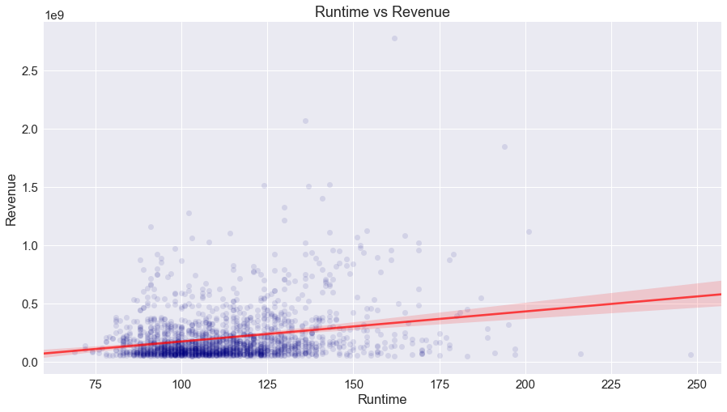

```python
# Plotting runtime vs revenue
plt.figure(figsize = (15,8))
sns.set(style="darkgrid", font_scale=1.5)
sns.regplot(x="runtime", y="revenue", data=toprev,
            scatter_kws={"color":"navy","alpha":0.1},
            line_kws={"color":"red","alpha":0.7});
plt.title('Runtime vs Revenue')
plt.xlabel('Runtime');
plt.ylabel('Revenue');
```

#### Regplot Observations

I can see that the bulk of the movies seem to fall within the 75 to 150 minute range, but this is an estimate. The bulk of the revenue also seems to be clustered toward the bottom, with some clear outliers. The trendline is fairly low--though I suspect it would be lower without the outliers pulling it up--indicating that runtime may not be reflective of revenue.

Back to Top

### Runtime Distribution

I want to get a better idea of how runtime is distributed.

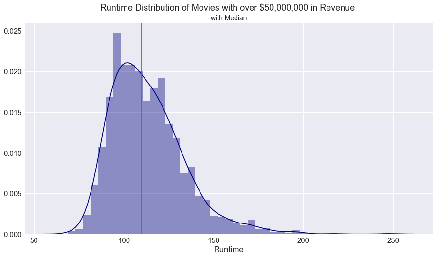

```python
# Create a distribution plot
plt.figure(figsize = (15,8))
sns.set(style="darkgrid", font_scale=1.5)
plt.suptitle('Runtime Distribution of Movies with over $50,000,000 in Revenue', x= .51, y=.95, fontsize=18)
plt.title('with Median', fontsize=14)
sns.distplot(toprev["runtime"], color='navy')
plt.xlabel('Runtime');
plt.axvline(x=toprev["runtime"].median(), color = 'fuchsia');
```

```python
# Getting statistics on runtime
toprev.runtime.describe()
```

```
count    1835.000000
mean      113.087738
std        20.423099
min        69.000000
25%        98.000000
50%       110.000000
75%       124.000000
max       248.000000
Name: runtime, dtype: float64
```

#### Runtime Distribution Observations

The histogram shows that the data is skewed right, and the average runtime is 113 minutes. The bulk of movies fall between 98 and 124 minutes.

Back to Top

### Toprev Heatmap

I want to see if the smaller dataset changes anything with the correlation from the previous question.

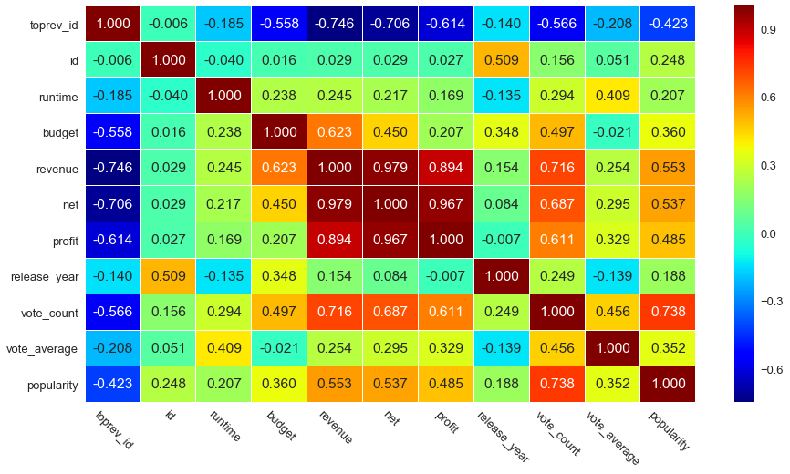

```python
# Create heatmap of dfnz
plt.figure(figsize = (15,8))
sns.set(font_scale=1.3)
g = sns.heatmap(toprev[list(toprev)].corr(), annot=True, fmt = ".3f", cmap = "jet", linewidths= 0.01)
plt.xticks(rotation=-45);
```

#### Heatmap Observations

In the previous question, the heatmap showed a correlation of 0.249 between runtime and revenue. In this dataframe, that correlation went down to 0.245. In both cases this is considered insignificant.

### Runtime Summary

In regards high revenue movies (revenue greater than $50,000,000), it can be said that they have an average runtime of 113 minutes, and the bulk fall into a range of 98 to 124 minutes.

Looking at the relationship between `runtime` and `revenue` for high revenue movies, at 0.245 there is not a strong correlation between the two.

Back to Top

## Vote Count

Next, I want to look at `vote_count` to see how it relates to `revenue`.

### Vote Count vs Revenue Scatterplot with Regression

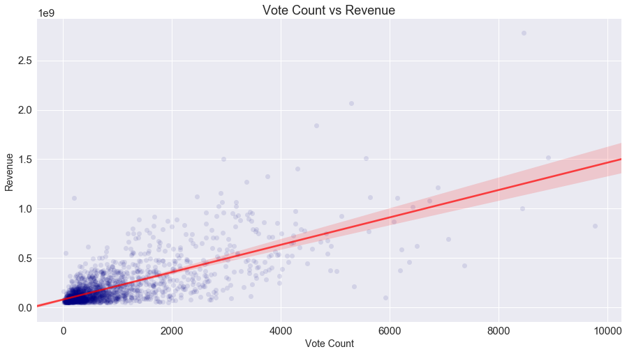

```python
# Plotting vote_count vs revenue
plt.figure(figsize = (15,8))
sns.set(style="darkgrid", font_scale=1.5)
sns.regplot(x="vote_count", y="revenue", data=toprev,
            scatter_kws={"color":"navy","alpha":0.1},
            line_kws={"color":"red","alpha":0.7});
plt.title('Vote Count vs Revenue')
plt.xlabel('Vote Count', fontsize=14);
plt.ylabel('Revenue', fontsize=14);
```

#### Scatterplot Observations

Looking at the trendline, there seems to be better correlation between `vote_count` and `revenue`. Initially, this seems promising, but I have a concern that movies that came out prior to around 2000 do not have the same volume of votes that post-year 2000 movies have.

Back to Top

### Vote Count vs Year

I suspect that the number of movies in the dataset may be skewed towards more recent years.

```python
# Some basic stats
toprev.vote_count.describe()
```

```
count    1835.000000
mean      913.781471
std      1113.628335
min        13.000000
25%       242.000000
50%       516.000000
75%      1102.500000
max      9767.000000
Name: vote_count, dtype: float64
```

[figure not shown]

```python
# Plotting vote_count vs year
plt.figure(figsize = (15,8))
sns.set(style="darkgrid", font_scale=1.5)
sns.regplot(x="release_year", y="vote_count", data=toprev, fit_reg=False,
            scatter_kws={"color":"navy","alpha":0.1});
plt.suptitle('Vote Count per Year', x= .51, y=.95, fontsize=18)
plt.title('with Median', fontsize=14)
plt.xlabel('Year');
plt.ylabel('Vote Count');
plt.axhline(y=toprev["vote_count"].mean(), color = 'fuchsia');
```

In the plot above, the movies range from 1960 to 2015, and the closer you get to 2015, the more movies there are, and the higher the number of votes.

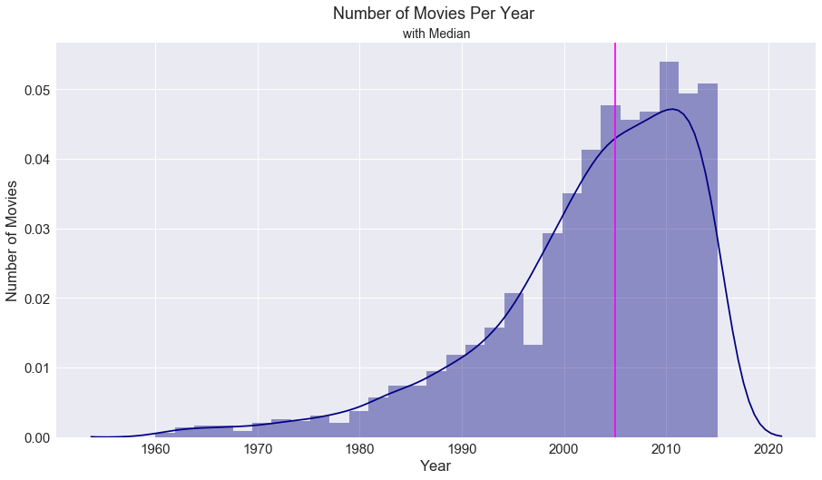

```python
# Getting a distribution of release year
plt.figure(figsize = (15,8))
sns.set(style="darkgrid", font_scale=1.5)
sns.distplot(toprev["release_year"], color='navy')
plt.suptitle('Number of Movies Per Year', x= .51, y=.95, fontsize=18)
plt.title('with Median', fontsize=14)
plt.xlabel('Year');
plt.ylabel('Number of Movies');
plt.axvline(x=toprev["release_year"].median(), color = 'fuchsia');
```

The distribution is skewed left pretty strongly. It appears to really start going up around the year 2000. I want to see how many movies came out before and after the year 2000.

```python
len(toprev[toprev.release_year >= 2000])
```

```
1291
```

```python
len(toprev[toprev.release_year < 2000])
```

```
544
```

The `toprev` dataframe contains 1291 movies from the year 2000 on, and only 544 movies before 2000. I want to check vote counts for those two segments.

```python
toprev[toprev.release_year >= 2000].vote_count.sum()
```

```
1351980
```

```python
toprev[toprev.release_year < 2000].vote_count.sum()
```

```
324809
```

#### Vote Count vs Year Observations

There are far more movies in the dataframe from 2000 on than there are prior to 2000. This is reflected in `vote count` as well.

Back to Top

### Vote Count vs Revenue - Year 2000 through 2015

I want to see if there is any difference between the full `toprev` dataframe and only movies from 2000 and on.

```python
# Create a dataframe where the year is greater than 2000
year = toprev[toprev.release_year >= 2000]
```

```python
# Correlation and p-value for the 'year' dataframe
stats.pearsonr(year['revenue'], year['vote_count'])
```

```
(0.7395673113049493, 7.204398229308846e-224)
```

The correlation between vote count and revenue is actually a little better.

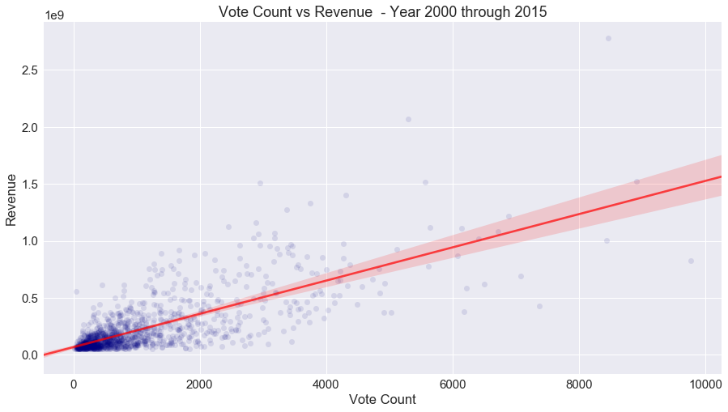

```python
# Regplot with the narrowed range of the 'year' dataframe
plt.figure(figsize = (15,8))
sns.set(style="darkgrid", font_scale=1.5)
sns.regplot(x="vote_count", y="revenue", data=year,
            scatter_kws={"color":"navy","alpha":0.1},
            line_kws={"color":"red","alpha":0.7});
plt.title('Vote Count vs Revenue  - Year 2000 through 2015');
plt.xlabel('Vote Count');
plt.ylabel('Revenue');
```

It appears that since there are far fewer movies prior to 2000, and thus less total votes for that segment of time, it doesn't have much effect on the entire `toprev` dataframe. If anything, it actually brings the correlation between the two variables down, but the change is marginal at best.

#### Vote Count Summary

Another property of high revenue movies is a higher vote count. In the previous section on runtime, the heatmap showed `vote_count` to have a correlation with `revenue` of 0.716, which is fairly strong. I had a concern about the number of movies in the 2000s compared to before 2000 and how that affected vote count vs revenue, but there was only a negligble effect on the correlation.

Back to Top

## Genres

Lastly, I want to explore `genres` and how they relate to revenue. I will continue to use the `toprev` dataframe for this.

### Splitting the Genres Column

The `genres` column is mostly populated with more than one genre per movie, separated by a pipe. Additionally, each movie can have a different number of genres. This makes it difficult to deal with. The only way to do it is to drop the `genres` column, split it, and join the results back. However, this effectively creates duplicate rows of the same movie, where all the data is the same except the genre. So a movie where the `genres` column is `Action|Adventure|Comedy` now has 3 rows, one for each of those 3 genres. This also artificially inflates the size of the dataframe.

```python
# Splitting out genres and joining them back in
toprev_genres = toprev.drop('genres', axis=1).join(toprev['genres'].str.split('|', expand=True).stack().reset_index(level=1, drop=True).rename('genre'))
```

```python
# Note the duplicate rows
toprev_genres.head(20)
```

|  | toprev_id | id | imdb_id | original_title | cast | director | runtime | budget | revenue | net | profit | success | production_companies | release_date | release_year | vote_count | vote_average | popularity | genre |
| --- | --- | --- | --- | --- | --- | --- | --- | --- | --- | --- | --- | --- | --- | --- | --- | --- | --- | --- | --- |
| 0 | 5 | 135397 | tt0369610 | Jurassic World | Chris Pratt\|Bryce Dallas Howard\|Irrfan Khan\|Vi... | Colin Trevorrow | 124 | 150000000 | 1513528810 | 1363528810 | 1213528810 | Success | Universal Studios\|Amblin Entertainment\|Legenda... | 6/9/15 | 2015 | 5562 | 6.5 | 32.985763 | Action |
| 0 | 5 | 135397 | tt0369610 | Jurassic World | Chris Pratt\|Bryce Dallas Howard\|Irrfan Khan\|Vi... | Colin Trevorrow | 124 | 150000000 | 1513528810 | 1363528810 | 1213528810 | Success | Universal Studios\|Amblin Entertainment\|Legenda... | 6/9/15 | 2015 | 5562 | 6.5 | 32.985763 | Adventure |
| 0 | 5 | 135397 | tt0369610 | Jurassic World | Chris Pratt\|Bryce Dallas Howard\|Irrfan Khan\|Vi... | Colin Trevorrow | 124 | 150000000 | 1513528810 | 1363528810 | 1213528810 | Success | Universal Studios\|Amblin Entertainment\|Legenda... | 6/9/15 | 2015 | 5562 | 6.5 | 32.985763 | Science Fiction |
| 0 | 5 | 135397 | tt0369610 | Jurassic World | Chris Pratt\|Bryce Dallas Howard\|Irrfan Khan\|Vi... | Colin Trevorrow | 124 | 150000000 | 1513528810 | 1363528810 | 1213528810 | Success | Universal Studios\|Amblin Entertainment\|Legenda... | 6/9/15 | 2015 | 5562 | 6.5 | 32.985763 | Thriller |
| 1 | 223 | 76341 | tt1392190 | Mad Max: Fury Road | Tom Hardy\|Charlize Theron\|Hugh Keays-Byrne\|Nic... | George Miller | 120 | 150000000 | 378436354 | 228436354 | 78436354 | Success | Village Roadshow Pictures\|Kennedy Miller Produ... | 5/13/15 | 2015 | 6185 | 7.1 | 28.419936 | Action |
| 1 | 223 | 76341 | tt1392190 | Mad Max: Fury Road | Tom Hardy\|Charlize Theron\|Hugh Keays-Byrne\|Nic... | George Miller | 120 | 150000000 | 378436354 | 228436354 | 78436354 | Success | Village Roadshow Pictures\|Kennedy Miller Produ... | 5/13/15 | 2015 | 6185 | 7.1 | 28.419936 | Adventure |
| 1 | 223 | 76341 | tt1392190 | Mad Max: Fury Road | Tom Hardy\|Charlize Theron\|Hugh Keays-Byrne\|Nic... | George Miller | 120 | 150000000 | 378436354 | 228436354 | 78436354 | Success | Village Roadshow Pictures\|Kennedy Miller Produ... | 5/13/15 | 2015 | 6185 | 7.1 | 28.419936 | Science Fiction |
| 1 | 223 | 76341 | tt1392190 | Mad Max: Fury Road | Tom Hardy\|Charlize Theron\|Hugh Keays-Byrne\|Nic... | George Miller | 120 | 150000000 | 378436354 | 228436354 | 78436354 | Success | Village Roadshow Pictures\|Kennedy Miller Produ... | 5/13/15 | 2015 | 6185 | 7.1 | 28.419936 | Thriller |
| 2 | 356 | 262500 | tt2908446 | Insurgent | Shailene Woodley\|Theo James\|Kate Winslet\|Ansel... | Robert Schwentke | 119 | 110000000 | 295238201 | 185238201 | 75238201 | Success | Summit Entertainment\|Mandeville Films\|Red Wago... | 3/18/15 | 2015 | 2480 | 6.3 | 13.112507 | Adventure |
| 2 | 356 | 262500 | tt2908446 | Insurgent | Shailene Woodley\|Theo James\|Kate Winslet\|Ansel... | Robert Schwentke | 119 | 110000000 | 295238201 | 185238201 | 75238201 | Success | Summit Entertainment\|Mandeville Films\|Red Wago... | 3/18/15 | 2015 | 2480 | 6.3 | 13.112507 | Science Fiction |
| 2 | 356 | 262500 | tt2908446 | Insurgent | Shailene Woodley\|Theo James\|Kate Winslet\|Ansel... | Robert Schwentke | 119 | 110000000 | 295238201 | 185238201 | 75238201 | Success | Summit Entertainment\|Mandeville Films\|Red Wago... | 3/18/15 | 2015 | 2480 | 6.3 | 13.112507 | Thriller |
| 3 | 2 | 140607 | tt2488496 | Star Wars: The Force Awakens | Harrison Ford\|Mark Hamill\|Carrie Fisher\|Adam D... | J.J. Abrams | 136 | 200000000 | 2068178225 | 1868178225 | 1668178225 | Success | Lucasfilm\|Truenorth Productions\|Bad Robot | 12/15/15 | 2015 | 5292 | 7.5 | 11.173104 | Action |
| 3 | 2 | 140607 | tt2488496 | Star Wars: The Force Awakens | Harrison Ford\|Mark Hamill\|Carrie Fisher\|Adam D... | J.J. Abrams | 136 | 200000000 | 2068178225 | 1868178225 | 1668178225 | Success | Lucasfilm\|Truenorth Productions\|Bad Robot | 12/15/15 | 2015 | 5292 | 7.5 | 11.173104 | Adventure |
| 3 | 2 | 140607 | tt2488496 | Star Wars: The Force Awakens | Harrison Ford\|Mark Hamill\|Carrie Fisher\|Adam D... | J.J. Abrams | 136 | 200000000 | 2068178225 | 1868178225 | 1668178225 | Success | Lucasfilm\|Truenorth Productions\|Bad Robot | 12/15/15 | 2015 | 5292 | 7.5 | 11.173104 | Science Fiction |
| 3 | 2 | 140607 | tt2488496 | Star Wars: The Force Awakens | Harrison Ford\|Mark Hamill\|Carrie Fisher\|Adam D... | J.J. Abrams | 136 | 200000000 | 2068178225 | 1868178225 | 1668178225 | Success | Lucasfilm\|Truenorth Productions\|Bad Robot | 12/15/15 | 2015 | 5292 | 7.5 | 11.173104 | Fantasy |
| 4 | 6 | 168259 | tt2820852 | Furious 7 | Vin Diesel\|Paul Walker\|Jason Statham\|Michelle ... | James Wan | 137 | 190000000 | 1506249360 | 1316249360 | 1126249360 | Success | Universal Pictures\|Original Film\|Media Rights ... | 4/1/15 | 2015 | 2947 | 7.3 | 9.335014 | Action |
| 4 | 6 | 168259 | tt2820852 | Furious 7 | Vin Diesel\|Paul Walker\|Jason Statham\|Michelle ... | James Wan | 137 | 190000000 | 1506249360 | 1316249360 | 1126249360 | Success | Universal Pictures\|Original Film\|Media Rights ... | 4/1/15 | 2015 | 2947 | 7.3 | 9.335014 | Crime |
| 4 | 6 | 168259 | tt2820852 | Furious 7 | Vin Diesel\|Paul Walker\|Jason Statham\|Michelle ... | James Wan | 137 | 190000000 | 1506249360 | 1316249360 | 1126249360 | Success | Universal Pictures\|Original Film\|Media Rights ... | 4/1/15 | 2015 | 2947 | 7.3 | 9.335014 | Thriller |
| 5 | 131 | 281957 | tt1663202 | The Revenant | Leonardo DiCaprio\|Tom Hardy\|Will Poulter\|Domhn... | Alejandro González Iñárritu | 156 | 135000000 | 532950503 | 397950503 | 262950503 | Success | Regency Enterprises\|Appian Way\|CatchPlay\|Anony... | 12/25/15 | 2015 | 3929 | 7.2 | 9.110700 | Western |
| 5 | 131 | 281957 | tt1663202 | The Revenant | Leonardo DiCaprio\|Tom Hardy\|Will Poulter\|Domhn... | Alejandro González Iñárritu | 156 | 135000000 | 532950503 | 397950503 | 262950503 | Success | Regency Enterprises\|Appian Way\|CatchPlay\|Anony... | 12/25/15 | 2015 | 3929 | 7.2 | 9.110700 | Drama |

```python
len(toprev_genres)
```

```
5185
```

The dataframe went from 1835 rows of data, to 5185 rows of data.

Back to Top

### Counting Genres

I want to see how many times each genre appears in this dataframe.

```python
# Create a dataframe 'genre_count' to see the number of occurrences per genre
genre_count = toprev_genres['genre'].value_counts().sort_values(ascending=False)
```

```python
genre_count
```

```
Drama              692
Comedy             660
Action             641
Thriller           571
Adventure          505
Family             292
Romance            291
Crime              289
Science Fiction    284
Fantasy            255
Horror             170
Mystery            158
Animation          149
History             70
Music               65
War                 63
Western             25
Documentary          5
Name: genre, dtype: int64
```

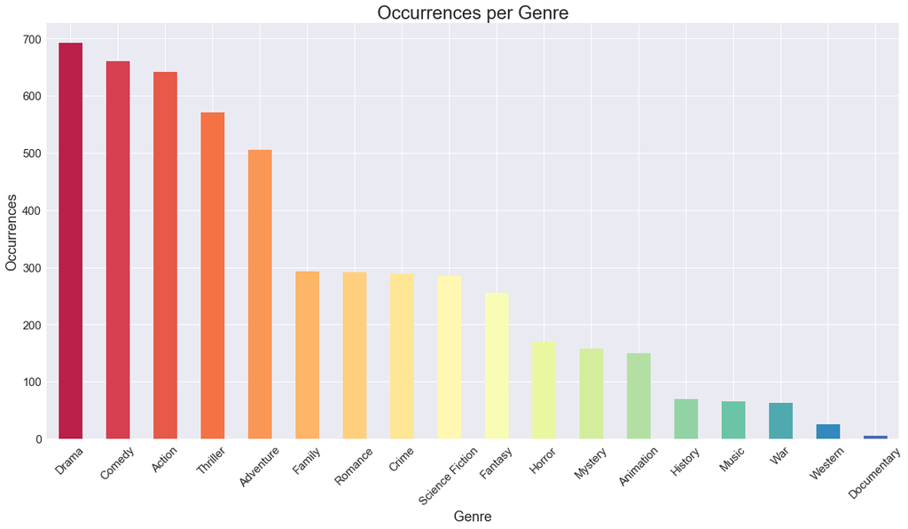

```python
# Create a bar chart displaying the number of occurrences per genre
sns.set(style="darkgrid", font_scale=1.5)
sns.set_palette(sns.color_palette('Spectral', 18))
genre_count.plot(kind='bar', figsize = (20,10))
plt.title('Occurrences per Genre', fontsize=24)
plt.xlabel('Genre', fontsize=18);
plt.ylabel('Occurrences', fontsize=18);
plt.xticks(rotation=45);
```

#### Counting Observations

The top five genres appearing in this dataset are drama, comedy, action, thriller, and adventure. These five are close to or exceeds double the amount of other genres. Since there is usually more than one genre per movie, this indicates to me that these top 5 are either 1) used excessively, or 2) are used as some kind of "main" genre, and the others are added in to narrow things down. It is unclear to me why that is necessary.

Back to Top

### Number of Genres per Movie

To get a better understanding the genres, I'm going to flip this around to see how many genres there are per movie.

```python
# Create a new dataframe for genres per movie
genre_pm = toprev_genres['original_title'].value_counts().sort_values(ascending=False)
```

```python
len(genre_pm)
```

```
1818
```

```python
# The top 15 movies with the most genres assigned to them
genre_pm.head(15)
```

```
Teenage Mutant Ninja Turtles        10
King Kong                            8
Annie                                8
Hercules                             7
The Three Musketeers                 7
Footloose                            7
Fantastic Four                       7
Total Recall                         7
Point Break                          6
Godzilla                             6
Ghostbusters II                      5
The Mummy                            5
Run All Night                        5
Spirit: Stallion of the Cimarron     5
Megamind                             5
Name: original_title, dtype: int64
```

```python
# Count the number of movies in relation to how many genres were assigned
genre_pm.value_counts()
```

```
3     635
2     433
4     339
1     255
5     146
7       5
8       2
6       2
10      1
Name: original_title, dtype: int64
```

This shows that there were 635 movies with 3 genres assigned to it, 433 movies with 2 genres assigned, etc.

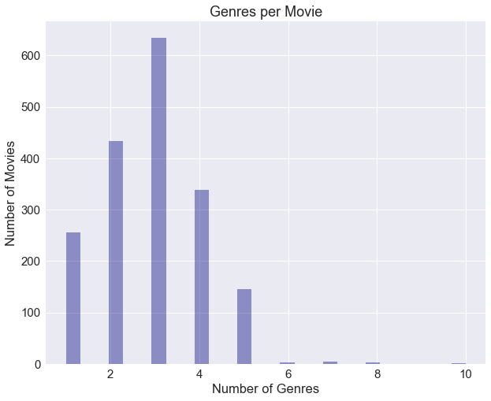

```python
# Create a distribution plot of genres per movie
plt.figure(figsize = (10,8))
sns.set(style="darkgrid", font_scale=1.5, palette='gnuplot2')
sns.distplot(genre_pm, color='navy', kde=False);
plt.title('Genres per Movie')
plt.xlabel('Number of Genres');
plt.ylabel('Number of Movies');
```

```python
# Get accurate statistics on genres per movie
genre_pm.describe()
```

```
count    1818.000000
mean        2.852035
std         1.180748
min         1.000000
25%         2.000000
50%         3.000000
75%         4.000000
max        10.000000
Name: original_title, dtype: float64
```

```python
# Mean number of genres per movie
genre_pm.mean()
```

```
2.852035203520352
```

#### Genres Per Movie Observations

When looking at the number of genres assigned per movie, counts of genres between one through five each have hundreds of movies with that many genres. There are only a few that go beyond five. Movies with three genres assigned have the highest count.

Back to Top

### Genre and Revenue

Lastly, I will explore genres against revenue.

```python
# Grouping by genre and summing the revenue for each
rpg = toprev_genres.groupby(['genre']).revenue.sum().sort_values(ascending=False)
rpg
```

```
genre
Action             161633154692
Adventure          158617492766
Comedy             119445068824
Drama              112857678510
Thriller           106485852980
Fantasy             83849240304
Family              83430386036
Science Fiction     81053855486
Romance             50827113984
Animation           50715274522
Crime               48036020141
Mystery             28283809237
Horror              21787581351
War                 11573017210
Music               10050540855
History              9352873320
Western              4221204729
Documentary           459335183
Name: revenue, dtype: int64
```

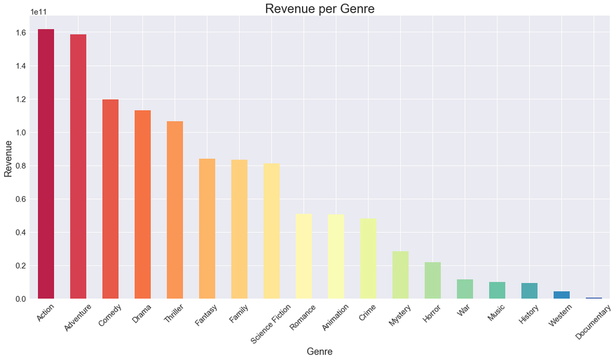

```python
# Create a bar chart displaying the revenue per genre
sns.set(style="darkgrid", font_scale=1.5)
sns.set_palette(sns.color_palette('Spectral', 18))
rpg.plot(kind='bar', figsize = (20,10))
plt.title('Revenue per Genre', fontsize=24)
plt.xlabel('Genre', fontsize=18);
plt.ylabel('Revenue', fontsize=18);
plt.xticks(rotation=45);
```

#### Genre vs Revenue Observations

The top five genres in terms of revenue are action, adventure, comedy, drama, and thriller.

### Genres Summary

With genres, I found that movies with high revenue most often have a genre of **drama, comedy, action, thriller** and **adventure**. Because these genres all have much higher counts than the rest, it leads me to believe that these are very broad genres used to describe a wide variety of movies. However, these genres would be another property of high revenue movies.

When you get down to **family, romance, crime, science fiction, fantasy, horror,** etc, this is perhaps a more accurate descriptor of the actual genre.

I found it interesting that the top 5 genres in terms of revenue were the same as the top 5 in occurrences, but they appear in a different order. For instance, **Drama** appeared the most, yet it was 4th in revenue. **Action** was tops in revenue, yet it was 3rd in total count. **Adventure** was 2nd in revenue, but 5th in occurrences.

Back to Top

# Conclusions

## Question 1

In question 1, I explored the financial aspect of what makes a movie successful or a failure. Specifically, the criteria for *success* was that the movie at a minimum doubled its budget in revenue. This was calculated in a new variable labeled as **profit**.

The results showed there were 2,008 successes and 1,797 failures, which is approximately a 53:47 success/failure rate. I arrived at this result after using less than half the original dataset because so many entries did not have revenue or budget data, and often both were missing.

It's important to keep in mind the criteria that was set for what is considered a success; there were 748 movies that still made money, just not double their budgets, which labeled them as failures. Since this is not a firm rule, movie studios are not bound by it, and could still decide to make sequels. I do not have marketing data for any movie, so it is entirely possible that a movie didn't have a huge marketing cost, and even though it didn't double its budget, it still made enough money for the studio to take a chance on making a sequel.

## Question 2

In question 2, I looked at what properties movies with high revenues (over $50 million) might have. I looked at three variables: runtime, vote count, and genres.

In regards to runtime, I found that movies with high revenues had an average runtime of 113 minutes, and the bulk fell into a range of between 98 and 124 minutes. This however, does not have a strong correlation to revenue, as when I plotted runtime and revenue the trend line was low, and the heatmap showed a very low correlation. However, that being said, logically speaking, I still think runtime can have an effect on a movie's revenue. For instance, a 3-hour movie likely turns some people off from seeing it in the theater because they don't want to sit through a movie that long. This is obviously the exception and not the rule, which is likely one reason the correlation is so low, but it is a consideration that studios likely take into account.

When looking at vote count, there seemed to be a fairly strong trend when I plotted it against revenue. I was initially concerned that the dataset skewing heavily toward recent movies in shear count was throwing off the analysis. I looked more closely at the number of movies and vote counts before and after the year 2000, and the trend remained fairly constant, so that was not an issue. Looking back at the heatmap, vote count had a moderately strong correlation to revenue at 0.716. In fact, it was the strongest correlation to revenue of all possible variables (net and profit are not useable to predict revenue).

The caveat to using vote count as a predictor to revenue is that it comes after the movie is released. So, it *could* be used as a predictor after the initial weekend run of the movie looking towards the long term success of the box office run. It could also be used as a predictor to how much people enjoyed the movie, and would want to see a sequel. For example, a movie might get a high amount of attendance through marketing and name recognition, but viewers left disappointed. Vote count could provide the studio with an idea of how well the movie was received, rather than simply relying on revenue alone. Some movies actually do better with streaming/Blu ray sales than they did in the box office.

With genres, I found that movies with high revenues had genres of **drama, comedy, action, thriller,** and **adventure** as the top 5, both in terms of occurrences and revenue, though in differing orders. However, those five had close to double the amount or more occurrences than the other genres. I believe that indicates that those top 5 cover are used too liberally, and that the others not on the top 5 are likely better descriptors of the type of movie it is. Additionally, the majority of movies in the dataset had more than 1 genre attached to it. Between the overuse of the top 5 genre labels, and multiple genres per movie, it is difficult to use genre as a predictor. A more targeted use of genre would likely yield better results.

Back to Top

```python
# Displays all the dataframes used in this report
%whos DataFrame
```

```
Variable        Type         Data/Info
--------------------------------------
df              DataFrame              id    imdb_id  <...>n[9770 rows x 15 columns]
dfnz            DataFrame              id    imdb_id  <...>n[3805 rows x 18 columns]
missing         DataFrame                          Tot<...>             0   0.000000
pc              DataFrame               id    imdb_id <...>n[1030 rows x 21 columns]
toprev          DataFrame          toprev_id      id  <...>n[1835 rows x 19 columns]
toprev_genres   DataFrame          toprev_id      id  <...>n[5185 rows x 19 columns]
year            DataFrame          toprev_id      id  <...>n[1291 rows x 19 columns]
```